# 04_rq2_station_typologies_v3_4

-- 04_rq2_station_typologies_v1.ipynb -- Estrutura 4.1 Introdução 4.2 Preparação dos dados 4.2.1 Carregamento dos dados 4.2.2 Seleção das features 4.3 Análise exploratória dos dados 4.3.1 Estatística descritiva describe() 4.3.2 Distribuição das variáveis histogramas 4.3.3 Correlação entre variáveis heatmap análise de correlações elevadas 4.3.4 Deteção de outliers e assimetrias boxplots skewness 4.3.5 Tratamento das assimetrias log1p() 4.3.6 Validação das transformações 4.3.6.1 comparação visual histogramas após log boxplots após log skewness após log 4.3.6.2 Conclusão 4.4 Redução de dimensionalidade (PCA) 4.4.1 Standardização das variáveis StandardScaler 4.4.2 Análise da variância explicada explained_variance_ratio cumulative_variance 4.4.3 Seleção do número de componentes 4.4.4 Interpretação dos componentes principais 4.4.5 Visualização dos componentes principais 4.5 K-Means 4.5.1 Seleção do número de clusters Elbow (SSE) Calinski-Harabasz Davies-Bouldin 4.5.2 Treino do modelo 4.5.3 Caracterização dos clusters 4.5.4 Distribuição espacial dos clusters 4.5.4 Avaliação - Silhouete para avaliação da qualidade da solução 4.6 DBSCAN 4.6.1 Seleção dos parâmetros 4.6.2 Treino do modelo 4.6.3 Caracterização dos clusters DBSCAN 4.6.4 Análise dos outliers  
4.6.5 Distribuição espaciacial dos clusters e outliers 4.7 Comparação dos métodos K-Means vs DBSCAN vs HDBSCAN 4.8 Síntese da RQ2

Metodologia: Explorar Perceber distribuições Perceber correlações Perceber outliers Medir assimetrias Aplicar log Validar log StandardScaler PCA Escolher K KMeans Interpretar DBSCAN HDBSCAN

Análise: clustering INPUTS: v30_features_cluster_posto

ALGORITMOS: KMeans DBSCAN Hierarchical DBSCAN

OUTPUTS: escolha de k perfis mapa dos clusters

# SETUP e Ligação à BD

```python
# ---------------------------------------
#           Setup e ligação à DB
# ---------------------------------------
import sys
import os

import numpy as np
import pandas as pd
import geopandas as gpd
import matplotlib.pyplot as plt
import seaborn as sns

from scipy.stats import skew
from sklearn.preprocessing import StandardScaler
from sklearn.decomposition import PCA
from sklearn.cluster import KMeans, DBSCAN
from sklearn.metrics import (
    silhouette_score,
    calinski_harabasz_score,
    davies_bouldin_score
)

from sqlalchemy import create_engine
from pathlib import Path

# adicionar o caminho - sobe um nível
#sys.path.append(os.path.abspath(".."))
#print(os.getcwd())

# encontrar o caminho para a raiz do projeto (/projeto)
projeto_path = os.path.abspath(os.path.join(os.getcwd(), ".."))

# adicionar o novo caminho ao sys.path, caso ainda não esteja
if(projeto_path not in sys.path):
    sys.path.append(projeto_path)

# funções para desenhar mapa por distrito com labels e contornos
#from libs.map_utils import get_limites_distrito, plot_postos_distrito
import importlib
import libs.map_utils as munic
#importlib.reload(libs.map_utils)
importlib.reload(munic)

#from libs.map_utils import plot_postos_distrito

# definir o diretorio para guardar as figuras e quadros para o relatório
FIG_DIR = Path("../outputs/figures")
FIG_DIR.mkdir(parents=True, exist_ok=True)

TABLE_DIR = Path("../outputs/tables")
TABLE_DIR.mkdir(parents=True, exist_ok=True)


# adicionar a pasta "projeto" ao sys.path
from db.config import DB_CONFIG

# função para criar a engine à bd remota
def get_engine():
    return create_engine(
        f"postgresql+psycopg2://{DB_CONFIG['user']}:{DB_CONFIG['password']}@"
        f"{DB_CONFIG['host']}:{DB_CONFIG['port']}/{DB_CONFIG['dbname']}"
    )

# cria a engine
engine = get_engine()
#print(engine)
```

```python
# ---------------------------------------------
# Criação do ambiente para a análise
# ---------------------------------------------

"""
    - variáveis para analisar:
        -- por distrito
        -- gráfico - dimensão
        -- labels do gráfico
"""
# distrito
DISTRITO = "Coimbra"
EXCLUDES = ["Lisboa", "Porto"]

# plot dos gráfics
FIGSIZE = (10, 10)
SHOW_LABELS = True

# variáveis para o mapa
VARIAVEIS_MAPA = [
    "x"
]
```

## 4. Tipologias de utilização dos postos

```python
# ---------------------------------------
# Funções auxiliares
# ---------------------------------------

def read_sql(query):
    return pd.read_sql(query, engine)

def read_gdf(query, geom_col="geom"):
    return gpd.read_postgis(query, engine, geom_col=geom_col)

def anonymise_station_labels(df, id_col="id_charging_station", label_col="station_label"):
    """
        Creates anonymised station labels for sensivel data
    """
    df_out = df.copy()

    df_out[label_col] = [
        f"CS{i:03d}"
        for i in range(1, len(df_out) + 1)
    ]

    return df_out
```

## 4.2 Preparação dos dados

### 4.2.1 Loading dos dados para a base analítica

```python
# ---------------------------------------------
# Loading dos dados
# ---------------------------------------------
df = read_sql("SELECT * FROM v30_features_cluster_posto_clean")
df.head()
```

|  | id_charging_station | distrito | municipio | dtmn | nuts_3 | nuts_2 | nuts_1 | geom | n_sessoes | energia_total_kwh | ... | tem_rapido | n_conectores_dc | n_conectores_rapidos | sessoes_por_evse_instalado | sessoes_por_conector_instalado | kwh_por_kw_instalado | taxa_conectores_ativos | taxa_evse_ativos_estimados | kwh_por_sessao | kwh_por_utilizador |
| --- | --- | --- | --- | --- | --- | --- | --- | --- | --- | --- | --- | --- | --- | --- | --- | --- | --- | --- | --- | --- | --- |
| 0 | ABF-00005 | Faro | Albufeira | 0801 | Algarve | Algarve | Continente | 0101000020B30E00007680BE11E895C3C0F514A81E4976... | 1593 | 28851.940 | ... | 0 | 0 | 0 | 796.5 | 796.5 | 655.725909 | 2.0 | 1.5 | 18.111701 | 303.704632 |
| 1 | ABF-00006 | Faro | Albufeira | 0801 | Algarve | Algarve | Continente | 0101000020B30E0000629A94BE46E1C3C0B3ED8B10827C... | 838 | 13152.164 | ... | 0 | 0 | 0 | 419.0 | 419.0 | 298.912818 | 2.0 | 1.5 | 15.694706 | 196.300955 |
| 2 | ABF-00008 | Faro | Albufeira | 0801 | Algarve | Algarve | Continente | 0101000020B30E00006CD5DBC1473DC3C0D9C431388376... | 73 | 1571.021 | ... | 0 | 0 | 0 | 36.5 | 36.5 | 53.075034 | 1.0 | 1.0 | 21.520836 | 46.206500 |
| 3 | ABF-00009 | Faro | Albufeira | 0801 | Algarve | Algarve | Continente | 0101000020B30E0000EDF3A0E727FAC2C02C72B5524B75... | 61 | 1294.297 | ... | 0 | 0 | 0 | 30.5 | 30.5 | 87.452500 | 1.0 | 1.0 | 21.217984 | 53.929042 |
| 4 | ABF-00011 | Faro | Albufeira | 0801 | Algarve | Algarve | Continente | 0101000020B30E0000173570D83BFFB8C05C6F2D10B574... | 261 | 5908.194 | ... | 0 | 0 | 0 | 130.5 | 130.5 | 134.277136 | 2.0 | 1.5 | 22.636759 | 82.058250 |

5 rows × 52 columns

```python
df.shape
#df.info()
df.describe()
```

|  | n_sessoes | energia_total_kwh | energia_media_kwh | energia_mediana_kwh | duracao_media_min | duracao_mediana_min | meses_ativos | sessoes_mes_ativo | kwh_mes_ativo | n_utilizadores_unicos | ... | tem_rapido | n_conectores_dc | n_conectores_rapidos | sessoes_por_evse_instalado | sessoes_por_conector_instalado | kwh_por_kw_instalado | taxa_conectores_ativos | taxa_evse_ativos_estimados | kwh_por_sessao | kwh_por_utilizador |
| --- | --- | --- | --- | --- | --- | --- | --- | --- | --- | --- | --- | --- | --- | --- | --- | --- | --- | --- | --- | --- | --- |
| count | 9309.000000 | 9.309000e+03 | 9309.000000 | 9309.000000 | 9309.000000 | 9309.000000 | 9309.000000 | 9309.000000 | 9309.000000 | 9309.000000 | ... | 9309.000000 | 9309.000000 | 9309.000000 | 9309.000000 | 9309.000000 | 9309.000000 | 9309.000000 | 9309.000000 | 9309.000000 | 9177.000000 |
| mean | 932.007627 | 1.927436e+04 | 19.634389 | 17.550450 | 223.242229 | 201.322332 | 13.015684 | 60.640149 | 1293.223525 | 267.520679 | ... | 0.268557 | 0.904286 | 0.849393 | 391.228747 | 382.638368 | 265.325972 | 1.338481 | 1.156878 | 19.634389 | 272.247314 |
| std | 1571.435363 | 3.779033e+04 | 8.220173 | 9.006739 | 212.227763 | 218.889978 | 7.303887 | 96.061215 | 2533.110003 | 524.661404 | ... | 0.443233 | 1.828243 | 1.801221 | 576.889007 | 555.440525 | 489.303787 | 0.530983 | 0.388042 | 8.220173 | 803.985363 |
| min | 1.000000 | 1.000000e-01 | 0.100000 | 0.100000 | 2.133333 | 2.133333 | 1.000000 | 1.000000 | 0.100000 | 0.000000 | ... | 0.000000 | 0.000000 | 0.000000 | 0.250000 | 0.250000 | 0.000758 | 0.166667 | 0.166667 | 0.100000 | 0.100000 |
| 25% | 71.000000 | 1.322760e+03 | 13.748649 | 10.900000 | 48.381663 | 38.437933 | 7.000000 | 8.545455 | 148.216600 | 6.000000 | ... | 0.000000 | 0.000000 | 0.000000 | 48.000000 | 47.000000 | 38.556588 | 1.000000 | 1.000000 | 13.748649 | 41.300000 |
| 50% | 275.000000 | 5.006700e+03 | 19.411111 | 16.120000 | 150.462222 | 116.616383 | 12.000000 | 22.238095 | 413.608130 | 73.000000 | ... | 0.000000 | 0.000000 | 0.000000 | 161.000000 | 161.000000 | 125.293378 | 1.000000 | 1.000000 | 19.411111 | 72.625243 |
| 75% | 1123.000000 | 2.079130e+04 | 24.616923 | 22.710000 | 322.054828 | 255.850000 | 20.000000 | 75.478261 | 1467.191435 | 305.000000 | ... | 1.000000 | 2.000000 | 2.000000 | 477.000000 | 475.000000 | 306.031364 | 2.000000 | 1.500000 | 24.616923 | 158.840769 |
| max | 30675.000000 | 1.102679e+06 | 64.203886 | 64.700000 | 1679.850000 | 1679.850000 | 24.000000 | 2556.250000 | 91889.877750 | 13761.000000 | ... | 1.000000 | 20.000000 | 20.000000 | 5112.500000 | 5112.500000 | 8098.984054 | 2.500000 | 2.000000 | 64.203886 | 29979.701000 |

8 rows × 44 columns

```python
df[[
    "pct_verao",
    "pct_inverno"
]].describe()
```

|  | pct_verao | pct_inverno |
| --- | --- | --- |
| count | 9309.000000 | 9309.000000 |
| mean | 0.246284 | 0.248422 |
| std | 0.156840 | 0.192669 |
| min | 0.000000 | 0.000000 |
| 25% | 0.180851 | 0.155405 |
| 50% | 0.253552 | 0.215576 |
| 75% | 0.315708 | 0.272340 |
| max | 1.000000 | 1.000000 |

```python
df[[
    "pct_verao",
    "pct_inverno"
]].corr()
```

|  | pct_verao | pct_inverno |
| --- | --- | --- |
| pct_verao | 1.000000 | -0.577569 |
| pct_inverno | -0.577569 | 1.000000 |

```python
df.loc[
    (df["pct_verao"].isin([0, 1]))
    | (df["pct_inverno"].isin([0, 1])),
    ["meses_ativos", "pct_verao", "pct_inverno", "n_sessoes"]
].describe()
```

|  | meses_ativos | pct_verao | pct_inverno | n_sessoes |
| --- | --- | --- | --- | --- |
| count | 1683.000000 | 1683.000000 | 1683.000000 | 1683.000000 |
| mean | 2.970885 | 0.106874 | 0.419123 | 116.837790 |
| std | 2.061131 | 0.249331 | 0.371186 | 313.487484 |
| min | 1.000000 | 0.000000 | 0.000000 | 1.000000 |
| 25% | 1.000000 | 0.000000 | 0.000000 | 6.000000 |
| 50% | 3.000000 | 0.000000 | 0.381649 | 22.000000 |
| 75% | 4.000000 | 0.000000 | 0.708027 | 71.000000 |
| max | 17.000000 | 1.000000 | 1.000000 | 3574.000000 |

```python
df.groupby("meses_ativos")[
    ["pct_verao", "pct_inverno"]
].mean()
```

| meses_ativos | pct_verao | pct_inverno |
| --- | --- | --- |
| 1 | 0.108407 | 0.617257 |
| 2 | 0.064193 | 0.535729 |
| 3 | 0.068008 | 0.356866 |
| 4 | 0.094560 | 0.289361 |
| 5 | 0.166350 | 0.242646 |
| 6 | 0.271204 | 0.191490 |
| 7 | 0.340013 | 0.180432 |
| 8 | 0.342410 | 0.167863 |
| 9 | 0.333641 | 0.130850 |
| 10 | 0.308651 | 0.138893 |
| 11 | 0.277883 | 0.176698 |
| 12 | 0.261405 | 0.224981 |
| 13 | 0.271134 | 0.244935 |
| 14 | 0.254343 | 0.269830 |
| 15 | 0.263648 | 0.238153 |
| 16 | 0.252297 | 0.229221 |
| 17 | 0.288829 | 0.213434 |
| 18 | 0.285220 | 0.210262 |
| 19 | 0.283213 | 0.197050 |
| 20 | 0.287887 | 0.200879 |
| 21 | 0.292302 | 0.201760 |
| 22 | 0.282321 | 0.211162 |
| 23 | 0.271340 | 0.217034 |
| 24 | 0.255766 | 0.220705 |

```python
df["indice_sazonal_verao_inverno"] = (
    df["pct_verao"] - df["pct_inverno"]
)
df["indice_sazonal_verao_inverno"]
```

```
0       0.421218
1       0.307876
2       0.191781
3       0.491803
4       0.593870
          ...
9304    0.007194
9305   -0.642857
9306   -0.777778
9307    0.092251
9308    0.108434
Name: indice_sazonal_verao_inverno, Length: 9309, dtype: float64
```

```python
(df["pct_feriado"] > 0).mean()
```

```
np.float64(0.8052422386937372)
```

```python
pd.crosstab(df["tem_dc"], df["tem_rapido"])
```

| tem_rapido tem_dc | 0 | 1 |
| --- | --- | --- |
| 0 | 6615 | 1 |
| 1 | 194 | 2499 |

```python
df["nivel_potencia"] = 0
df.loc[df["tem_dc"] == 1, "nivel_potencia"] = 1
df.loc[df["tem_rapido"] == 1, "nivel_potencia"] = 2
```

```python
df.groupby("nivel_potencia")["potencia_max_kw"].median()
```

```
nivel_potencia
0    22.0
1    30.0
2    60.0
Name: potencia_max_kw, dtype: float64
```

```python
df[["pct_laboral", "pct_horario_laboral"]].corr()
```

|  | pct_laboral | pct_horario_laboral |
| --- | --- | --- |
| pct_laboral | 1.000000 | 0.835784 |
| pct_horario_laboral | 0.835784 | 1.000000 |

```python
df[
    ["pct_laboral", "pct_horario_laboral"]
].describe().T
```

|  | count | mean | std | min | 25% | 50% | 75% | max |
| --- | --- | --- | --- | --- | --- | --- | --- | --- |
| pct_laboral | 9309.0 | 0.567398 | 0.192449 | 0.0 | 0.478062 | 0.583333 | 0.687075 | 1.0 |
| pct_horario_laboral | 9309.0 | 0.416323 | 0.180742 | 0.0 | 0.333333 | 0.413333 | 0.491689 | 1.0 |

```python
diferenca_laboral = (
    df["pct_laboral"]
    - df["pct_horario_laboral"]
)

diferenca_laboral.describe(
    percentiles=[0.25, 0.50, 0.75, 0.90, 0.95, 0.99]
)
```

```
count    9309.000000
mean        0.151075
std         0.107523
min         0.000000
25%         0.074074
50%         0.154948
75%         0.211394
90%         0.268056
95%         0.315127
99%         0.465947
max         1.000000
dtype: float64
```

### 4.2.2 Seleção das variáveis

Variáveis de procura:

- sessoes_mes_ativo
- kwh_mes_ativo
- energia_media_kwh
- duracao_media_min

Variáveis temporais:

Variáveis técnicas:

- n_evse_instalados
- n_conectores_instalados
- potencia_max_kw
- potencia_total_kw
- tem_dc
- tem_rapido

Pressão relativa:

- sessoes_por_conector_instalado
- kwh_por_kw_instalado

```python
# ---------------------------------------------
# seleção das features (variáveis) =17
# ---------------------------------------------

features = [
    # Procura observada
    "sessoes_mes_ativo",
    "kwh_mes_ativo",
    "energia_media_kwh",
    "duracao_media_min",

    # Padrões temporais
    "pct_fim_semana",
    "pct_periodo_descanso",     # corresponde ao periodo noite, noite-tardia (22 e as 00) e madrugada -- alterado - melhor categorização para evita sobreposições entre diurno e laboral
    "pct_horario_laboral",      # 9h-17h59m de 2f a 6f (old:: "pct_laboral")
    "pct_verao",                # considerados os meses: 6, 7 e 8
    "pct_inverno",              # considerados os meses: 12, 1 e 2

    #"pct_diurno",              # 8h-20h
    #"pct_horario_laboral",     # 9-19h
    #"pct_sessoes_verao",       # considerados os meses: 6, 7, 8 e 9
    #"pct_sessoes_inverno",     # considerados os meses: 12, 1, 2 e 3


    # Características técnicas
    "n_evse_instalados",
    "n_conectores_instalados",
    "potencia_max_kw",
    "potencia_total_kw",
    "tem_dc",
    "tem_rapido",

    # Pressão relativa
    "sessoes_por_conector_instalado",
    "kwh_por_kw_instalado"
]
```

```python
# ---------------------------------------------
# Features
# ---------------------------------------------

df_features = df[[
    "id_charging_station",
    "distrito",
    "municipio",
    "dtmn",
    "nuts_3",
    "nuts_2",
    "nuts_1",
    "geom",
    *features
]].copy()

# anonimise id_charging_station and hidden geom
df_features = anonymise_station_labels(df_features)

cols_to_show = [
    "station_label",
    *df_features.columns.drop(["station_label", "id_charging_station", "geom"])
]

df_features[cols_to_show].head()
```

|  | station_label | distrito | municipio | dtmn | nuts_3 | nuts_2 | nuts_1 | sessoes_mes_ativo | kwh_mes_ativo | energia_media_kwh | ... | pct_verao | pct_inverno | n_evse_instalados | n_conectores_instalados | potencia_max_kw | potencia_total_kw | tem_dc | tem_rapido | sessoes_por_conector_instalado | kwh_por_kw_instalado |
| --- | --- | --- | --- | --- | --- | --- | --- | --- | --- | --- | --- | --- | --- | --- | --- | --- | --- | --- | --- | --- | --- |
| 0 | CS001 | Faro | Albufeira | 0801 | Algarve | Algarve | Continente | 159.300000 | 2885.194000 | 18.111701 | ... | 0.476460 | 0.055242 | 2 | 2 | 22.0 | 44.0 | 0 | 0 | 796.5 | 655.725909 |
| 1 | CS002 | Faro | Albufeira | 0801 | Algarve | Algarve | Continente | 93.111111 | 1461.351556 | 15.694706 | ... | 0.373508 | 0.065632 | 2 | 2 | 22.0 | 44.0 | 0 | 0 | 419.0 | 298.912818 |
| 2 | CS003 | Faro | Albufeira | 0801 | Algarve | Algarve | Continente | 4.055556 | 87.278944 | 21.520836 | ... | 0.410959 | 0.219178 | 2 | 2 | 7.4 | 29.6 | 0 | 0 | 36.5 | 53.075034 |
| 3 | CS004 | Faro | Albufeira | 0801 | Algarve | Algarve | Continente | 4.357143 | 92.449786 | 21.217984 | ... | 0.655738 | 0.163934 | 2 | 2 | 7.4 | 14.8 | 0 | 0 | 30.5 | 87.452500 |
| 4 | CS005 | Faro | Albufeira | 0801 | Algarve | Algarve | Continente | 13.736842 | 310.957579 | 22.636759 | ... | 0.659004 | 0.065134 | 2 | 2 | 22.0 | 44.0 | 0 | 0 | 130.5 | 134.277136 |

5 rows × 24 columns

```python
df_features.shape
```

```
(9309, 26)
```

```python
# -----------------------------------------------------------------------------------------
# verificar as qualidade das features do dataframe :: verifica se há valores NaN
# -----------------------------------------------------------------------------------------

df_features[features].isna().sum().sort_values(ascending=False)
```

```
sessoes_mes_ativo                 0
n_evse_instalados                 0
sessoes_por_conector_instalado    0
tem_rapido                        0
tem_dc                            0
potencia_total_kw                 0
potencia_max_kw                   0
n_conectores_instalados           0
pct_inverno                       0
kwh_mes_ativo                     0
pct_verao                         0
pct_horario_laboral               0
pct_periodo_descanso              0
pct_fim_semana                    0
duracao_media_min                 0
energia_media_kwh                 0
kwh_por_kw_instalado              0
dtype: int64
```

```python
# ---------------------------------------------
# Verificação de valores em falta
# ---------------------------------------------
missing = (
    df_features[features]
    .isna()
    .sum()
    .sort_values(ascending=False)
)

missing.head(17)
```

```
sessoes_mes_ativo                 0
n_evse_instalados                 0
sessoes_por_conector_instalado    0
tem_rapido                        0
tem_dc                            0
potencia_total_kw                 0
potencia_max_kw                   0
n_conectores_instalados           0
pct_inverno                       0
kwh_mes_ativo                     0
pct_verao                         0
pct_horario_laboral               0
pct_periodo_descanso              0
pct_fim_semana                    0
duracao_media_min                 0
energia_media_kwh                 0
kwh_por_kw_instalado              0
dtype: int64
```

```python
# Não foram identificados valores em falta nas variáveis selecionadas, pelo que não foi necessário proceder à imputação ou remoção de observações.
# como não há valores NaN, não é necessário fazer o dropna
#df_features = df_features.dropna(subset=features).copy()
```

## 4.3 Análise exploratória

### 4.3.1 Estatística descritiva

```python
# ------------------------------------------------------------------------------------------
# Resumo estatístico das colunas do dataframe - verificar outliers
# ------------------------------------------------------------------------------------------

df_features[features].describe().T
```

|  | count | mean | std | min | 25% | 50% | 75% | max |
| --- | --- | --- | --- | --- | --- | --- | --- | --- |
| sessoes_mes_ativo | 9309.0 | 60.640149 | 96.061215 | 1.000000 | 8.545455 | 22.238095 | 75.478261 | 2556.250000 |
| kwh_mes_ativo | 9309.0 | 1293.223525 | 2533.110003 | 0.100000 | 148.216600 | 413.608130 | 1467.191435 | 91889.877750 |
| energia_media_kwh | 9309.0 | 19.634389 | 8.220173 | 0.100000 | 13.748649 | 19.411111 | 24.616923 | 64.203886 |
| duracao_media_min | 9309.0 | 223.242229 | 212.227763 | 2.133333 | 48.381663 | 150.462222 | 322.054828 | 1679.850000 |
| pct_fim_semana | 9309.0 | 0.253102 | 0.141374 | 0.000000 | 0.192308 | 0.277598 | 0.328571 | 1.000000 |
| pct_periodo_descanso | 9309.0 | 0.320104 | 0.217849 | 0.000000 | 0.181818 | 0.296959 | 0.413551 | 1.000000 |
| pct_horario_laboral | 9309.0 | 0.416323 | 0.180742 | 0.000000 | 0.333333 | 0.413333 | 0.491689 | 1.000000 |
| pct_verao | 9309.0 | 0.246284 | 0.156840 | 0.000000 | 0.180851 | 0.253552 | 0.315708 | 1.000000 |
| pct_inverno | 9309.0 | 0.248422 | 0.192669 | 0.000000 | 0.155405 | 0.215576 | 0.272340 | 1.000000 |
| n_evse_instalados | 9309.0 | 2.130089 | 1.171915 | 1.000000 | 1.000000 | 2.000000 | 3.000000 | 12.000000 |
| n_conectores_instalados | 9309.0 | 2.155334 | 1.178767 | 1.000000 | 1.000000 | 2.000000 | 3.000000 | 12.000000 |
| potencia_max_kw | 9309.0 | 35.250373 | 44.889564 | 2.300000 | 11.000000 | 22.000000 | 50.000000 | 400.000000 |
| potencia_total_kw | 9309.0 | 109.522947 | 227.955548 | 2.300000 | 22.000000 | 44.000000 | 122.000000 | 7000.000000 |
| tem_dc | 9309.0 | 0.289290 | 0.453457 | 0.000000 | 0.000000 | 0.000000 | 1.000000 | 1.000000 |
| tem_rapido | 9309.0 | 0.268557 | 0.443233 | 0.000000 | 0.000000 | 0.000000 | 1.000000 | 1.000000 |
| sessoes_por_conector_instalado | 9309.0 | 382.638368 | 555.440525 | 0.250000 | 47.000000 | 161.000000 | 475.000000 | 5112.500000 |
| kwh_por_kw_instalado | 9309.0 | 265.325972 | 489.303787 | 0.000758 | 38.556588 | 125.293378 | 306.031364 | 8098.984054 |

### 4.3.2 Distribuição das variáveis

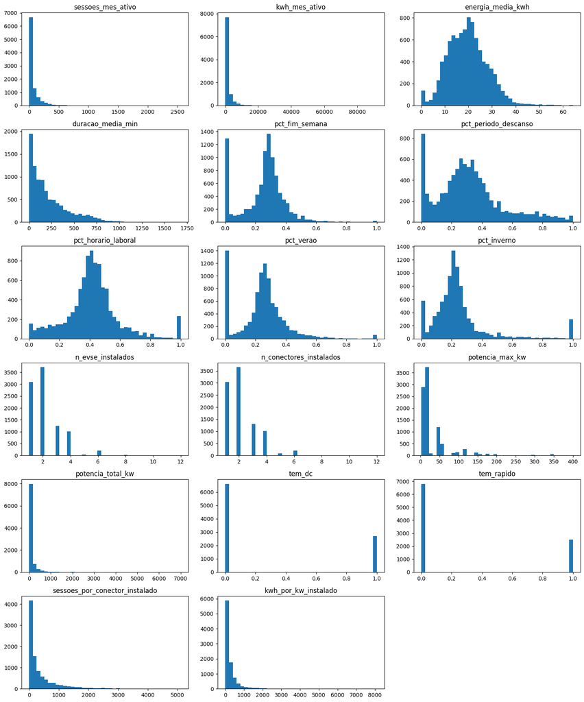

```python
# ---------------------------------------------
# Plot distribuição estatísitica das features
# count (Y) / max(X)
# ---------------------------------------------

fig, axes = plt.subplots(
    nrows=6,
    ncols=3,
    figsize=(15, 18)
)

axes = axes.flatten()

for i, col in enumerate(features):
    axes[i].hist(df_features[col].dropna(), bins=40)
    axes[i].set_title(col)
    axes[i].set_xlabel("")
    axes[i].set_ylabel("")

for j in range(i + 1, len(axes)):
    axes[j].axis("off")

plt.tight_layout()
plt.show()
```

### 4.3.3. Correlação entre variáveis

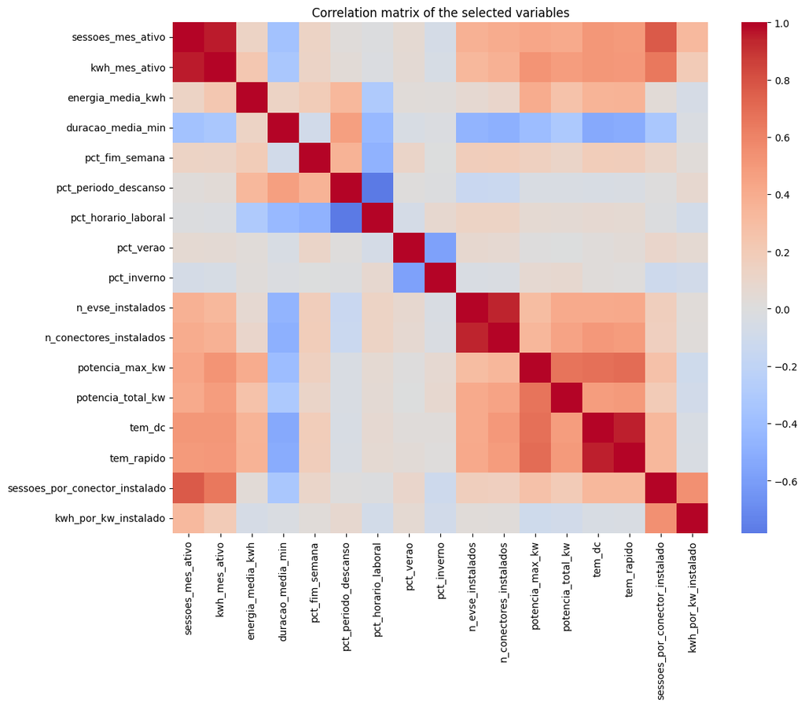

```python
# ---------------------------------------------
# Visão global de correlações entre features
# ---------------------------------------------

import seaborn as sns

corr = df_features[features].corr()

fig, ax = plt.subplots(figsize=(12, 10))

sns.heatmap(
    corr,
    annot=False,
    cmap="coolwarm",
    center=0,
    ax=ax
)

ax.set_title("Correlation matrix of the selected variables")
plt.tight_layout()

fig.savefig(
    FIG_DIR / f"correlation_matrix_of_the_selected_variables_NB04_4_3_3_01.png",
    dpi=300,
    bbox_inches="tight"
)
plt.show()
```

```python
infra = [
    "n_evse_instalados",
    "n_conectores_instalados",
    "potencia_max_kw",
    "potencia_total_kw",
    "tem_dc",
    "tem_rapido"
]

df[infra].corr().round(2)
```

|  | n_evse_instalados | n_conectores_instalados | potencia_max_kw | potencia_total_kw | tem_dc | tem_rapido |
| --- | --- | --- | --- | --- | --- | --- |
| n_evse_instalados | 1.00 | 0.94 | 0.30 | 0.41 | 0.41 | 0.42 |
| n_conectores_instalados | 0.94 | 1.00 | 0.34 | 0.45 | 0.50 | 0.49 |
| potencia_max_kw | 0.30 | 0.34 | 1.00 | 0.67 | 0.68 | 0.70 |
| potencia_total_kw | 0.41 | 0.45 | 0.67 | 1.00 | 0.48 | 0.50 |
| tem_dc | 0.41 | 0.50 | 0.68 | 0.48 | 1.00 | 0.95 |
| tem_rapido | 0.42 | 0.49 | 0.70 | 0.50 | 0.95 | 1.00 |

```python
# -----------------------------------------------------------------------------------------
# Análise às correlações elevadas - entre features
# -- analisar quais são os pares mais redundantes no dataset
# -----------------------------------------------------------------------------------------

corr_matrix = corr.abs()

mask = np.triu(
    np.ones_like(corr_matrix, dtype=bool),
    k=1
)

high_corr = (
    corr_matrix.where(mask)
               .stack()
               .sort_values(ascending=False)
)

high_corr.head(20)
```

```
sessoes_mes_ativo               kwh_mes_ativo                     0.951760
tem_dc                          tem_rapido                        0.949212
n_evse_instalados               n_conectores_instalados           0.939625
pct_periodo_descanso            pct_horario_laboral               0.783598
sessoes_mes_ativo               sessoes_por_conector_instalado    0.765147
potencia_max_kw                 tem_rapido                        0.698474
                                tem_dc                            0.683500
                                potencia_total_kw                 0.668937
kwh_mes_ativo                   sessoes_por_conector_instalado    0.648243
pct_verao                       pct_inverno                       0.577569
sessoes_por_conector_instalado  kwh_por_kw_instalado              0.540807
duracao_media_min               tem_dc                            0.539567
kwh_mes_ativo                   potencia_max_kw                   0.521922
duracao_media_min               tem_rapido                        0.518286
kwh_mes_ativo                   tem_dc                            0.506103
sessoes_mes_ativo               tem_dc                            0.505368
kwh_mes_ativo                   tem_rapido                        0.503426
n_conectores_instalados         tem_dc                            0.500408
sessoes_mes_ativo               tem_rapido                        0.497645
potencia_total_kw               tem_rapido                        0.496464
dtype: float64
```

```python
# ---------------------------------------------
#   Mapeamento de features para overleaf (en)
# ---------------------------------------------
feature_labels_en = {
    "sessoes_mes_ativo": "Sessions per active month",
    "kwh_mes_ativo": "Energy per active month",
    "energia_media_kwh": "Mean energy per session",
    "duracao_media_min": "Mean session duration",
    "pct_fim_semana": "Weekend sessions",
    "pct_periodo_descanso": "Rest-period sessions",
    "pct_horario_laboral": "Working-hours sessions",
    "pct_verao": "Summer sessions",
    "pct_inverno": "Winter sessions",
    "n_evse_instalados": "Installed EVSEs",
    "n_conectores_instalados": "Installed connectors",
    "potencia_max_kw": "Maximum power",
    "potencia_total_kw": "Total installed power",
    "tem_dc": "DC availability",
    "tem_rapido": "Fast-charging availability",
    "sessoes_por_conector_instalado": "Sessions per installed connector",
    "kwh_por_kw_instalado": "Energy per installed kW"
}
```

```python
corr = df_features[features].corr()
```

```python
corr_plot = corr.rename(
    index=feature_labels_en,
    columns=feature_labels_en
)
```

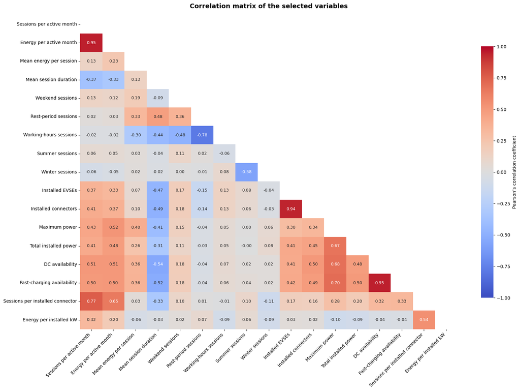

```python
mask = np.triu(np.ones_like(corr_plot, dtype=bool))

plt.figure(figsize=(17, 12))

sns.heatmap(
    corr_plot,
    mask=mask,
    annot=True,
    fmt=".2f",
    cmap="coolwarm",
    center=0,
    vmin=-1,
    vmax=1,
    annot_kws={"size": 9},
    cbar_kws={
        "shrink": 0.8,
        "label": "Pearson’s correlation coefficient"
    },
)

plt.title(
    "Correlation matrix of the selected variables",
    fontsize=14,
    fontweight="bold",
    pad=15,
)

plt.xticks(rotation=45, ha="right")
plt.yticks(rotation=0)
plt.tight_layout()

plt.savefig(
    FIG_DIR / "correlation_matrix_triangular_NB04_4_3_3_01.png",
    dpi=300,
    bbox_inches="tight",
)

plt.show()
```

```python
# -----------------------------------------------------------------------------------------
# Obter os valores da matriz triangular superior (sem a diagonal) em pares
#    para analisar as correlações acima de 0.7
# -----------------------------------------------------------------------------------------
corr_pairs = (
    corr_matrix
    .where(~mask)  # mantém só o triângulo inferior (o oposto da mask)
    .stack()
    .reset_index()
)
corr_pairs.columns = ["var1", "var2", "correlacao"]

# Filtrar só correlações fortes
#corr_pairs = corr_pairs[corr_pairs["correlacao"] > 0.7].sort_values("correlacao", ascending=False)

# Remover os pares onde var1 == var2
corr_pairs = corr_pairs[corr_pairs["var1"] != corr_pairs["var2"]]

# Ordenar por correlação mais forte
#corr_pairs = corr_pairs.sort_values("correlacao", ascending=False)
corr_pairs = corr_pairs[corr_pairs["correlacao"]> 0.6].sort_values("correlacao", ascending=False)

display(corr_pairs.head(15))
```

|  | var1 | var2 | correlacao |
| --- | --- | --- | --- |
| 17 | kwh_mes_ativo | sessoes_mes_ativo | 0.951760 |
| 251 | tem_rapido | tem_dc | 0.949212 |
| 179 | n_conectores_instalados | n_evse_instalados | 0.939625 |
| 107 | pct_horario_laboral | pct_periodo_descanso | 0.783598 |
| 255 | sessoes_por_conector_instalado | sessoes_mes_ativo | 0.765147 |
| 249 | tem_rapido | potencia_max_kw | 0.698474 |
| 232 | tem_dc | potencia_max_kw | 0.683500 |
| 215 | potencia_total_kw | potencia_max_kw | 0.668937 |
| 256 | sessoes_por_conector_instalado | kwh_mes_ativo | 0.648243 |

```python
# ---------------------------------------------
# Filtragem com corr > 0.6
# ---------------------------------------------
high_corr[high_corr > 0.6]
```

```
sessoes_mes_ativo     kwh_mes_ativo                     0.951760
tem_dc                tem_rapido                        0.949212
n_evse_instalados     n_conectores_instalados           0.939625
pct_periodo_descanso  pct_horario_laboral               0.783598
sessoes_mes_ativo     sessoes_por_conector_instalado    0.765147
potencia_max_kw       tem_rapido                        0.698474
                      tem_dc                            0.683500
                      potencia_total_kw                 0.668937
kwh_mes_ativo         sessoes_por_conector_instalado    0.648243
dtype: float64
```

```python
# ---------------------------------------------
# Filtragem com corr > 0.8
# ---------------------------------------------
high_corr[high_corr > 0.8]
```

```
sessoes_mes_ativo  kwh_mes_ativo              0.951760
tem_dc             tem_rapido                 0.949212
n_evse_instalados  n_conectores_instalados    0.939625
dtype: float64
```

```python
# ---------------------------------------------------------------------------------------------------------------------------------
# Correlação entre as variáveis antes do tratamento - redução e aplicação de métricas de standardization
# ---------------------------------------------------------------------------------------------------------------------------------

corr["potencia_total_kw"].sort_values(ascending=False)
```

```
potencia_total_kw                 1.000000
potencia_max_kw                   0.668937
tem_rapido                        0.496464
tem_dc                            0.484255
kwh_mes_ativo                     0.477702
n_conectores_instalados           0.447294
n_evse_instalados                 0.414536
sessoes_mes_ativo                 0.409648
energia_media_kwh                 0.256003
sessoes_por_conector_instalado    0.196973
pct_fim_semana                    0.110366
pct_inverno                       0.075968
pct_horario_laboral               0.047782
pct_verao                        -0.004099
pct_periodo_descanso             -0.034078
kwh_por_kw_instalado             -0.087735
duracao_media_min                -0.312607
Name: potencia_total_kw, dtype: float64
```

### 4.3.4 Deteção de outliers e assimetrias

Objetivo: - As distribuições são adequadas para PCA e K-Means?

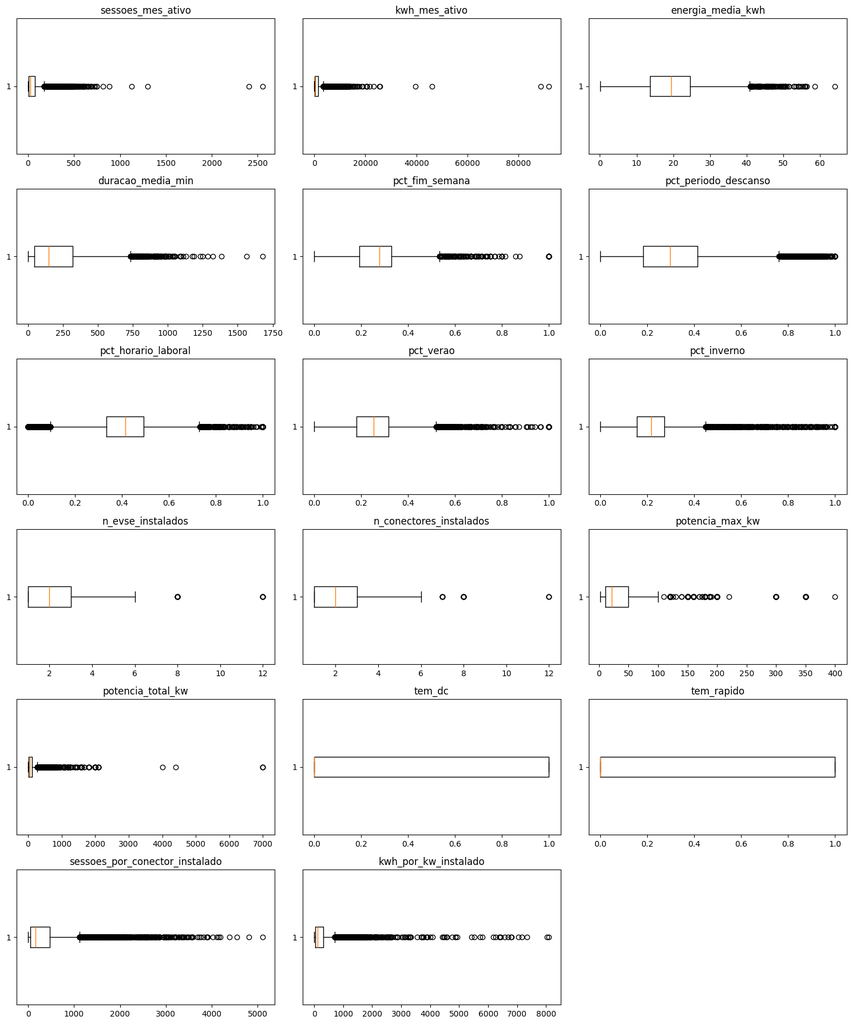

```python
# ---------------------------------------------
# Boxplots
# ---------------------------------------------

fig, axes = plt.subplots(
    nrows=6,
    ncols=3,
    figsize=(15,18)
)

axes = axes.flatten()

for i, col in enumerate(features):
    axes[i].boxplot(
        df_features[col].dropna(),
        vert=False
    )
    axes[i].set_title(col)

for j in range(i + 1, len(axes)):
    axes[j].axis("off")

plt.tight_layout()
plt.show()
```

```python
# ---------------------------------------------
# Skewness
# ---------------------------------------------

from scipy.stats import skew

skew_original = pd.DataFrame({
    "feature": features,
    "skew": skew(
        df_features[features],
        bias=False
    )
})

skew_original["abs_skew"] = (
    skew_original["skew"].abs()
)

skew_original.sort_values(
    by="abs_skew",
    ascending=False
)
```

|  | feature | skew | abs_skew |
| --- | --- | --- | --- |
| 12 | potencia_total_kw | 12.617759 | 12.617759 |
| 1 | kwh_mes_ativo | 12.255534 | 12.255534 |
| 16 | kwh_por_kw_instalado | 6.788429 | 6.788429 |
| 0 | sessoes_mes_ativo | 5.991166 | 5.991166 |
| 11 | potencia_max_kw | 3.648844 | 3.648844 |
| 15 | sessoes_por_conector_instalado | 2.698340 | 2.698340 |
| 8 | pct_inverno | 2.296931 | 2.296931 |
| 9 | n_evse_instalados | 1.586706 | 1.586706 |
| 3 | duracao_media_min | 1.412077 | 1.412077 |
| 10 | n_conectores_instalados | 1.404402 | 1.404402 |
| 14 | tem_rapido | 1.044563 | 1.044563 |
| 13 | tem_dc | 0.929549 | 0.929549 |
| 7 | pct_verao | 0.866229 | 0.866229 |
| 5 | pct_periodo_descanso | 0.821595 | 0.821595 |
| 6 | pct_horario_laboral | 0.586051 | 0.586051 |
| 2 | energia_media_kwh | 0.412240 | 0.412240 |
| 4 | pct_fim_semana | 0.053990 | 0.053990 |

### 4.3.5 Tratamento das Assimetrias (log1p())

```python
# -----------------------------------------------------------------------------------------
# Variáveis binárias não são transformadas
#   tem_dc
#   tem_rapido

# Variáveis percentuais [0,1] :: são mantidas na escala original
#   pct_fim_semana
#   pct_diurno
#   pct_horario_laboral
#   pct_sessoes_verao
#   pct_sessoes_inverno
# -----------------------------------------------------------------------------------------

log_features = [
    "sessoes_mes_ativo",
    "kwh_mes_ativo",
    "energia_media_kwh",
    "duracao_media_min",
    "n_evse_instalados",
    "n_conectores_instalados",
    "potencia_max_kw",
    "potencia_total_kw",
    "sessoes_por_conector_instalado",
    "kwh_por_kw_instalado"
]
```

```python
df_model = df_features.copy()

# df_model.describe().T
# df_model.shape
# df_model.dtypes

for col in log_features:
    df_model[f"log_{col}"] = np.log1p(df_model[col])
```

```python
# --------------------------------------------------------
# Features para o modelo após tratamento de assimetrias
#   log1p()
# --------------------------------------------------------
model_features = [
    "log_sessoes_mes_ativo",
    "log_kwh_mes_ativo",
    "log_energia_media_kwh",
    "log_duracao_media_min",

    "pct_fim_semana",
    "pct_periodo_descanso",
    "pct_horario_laboral",
    "pct_verao",
    "pct_inverno",

    "log_n_evse_instalados",
    "log_n_conectores_instalados",
    "log_potencia_max_kw",
    "log_potencia_total_kw",

    "tem_dc",
    "tem_rapido",

    "log_sessoes_por_conector_instalado",
    "log_kwh_por_kw_instalado"
]
```

```python
missing_model_features = [
    col
    for col in model_features
    if col not in df_model.columns
]

missing_model_features
```

```
[]
```

### 4.3.6 Validação das transformações

```python
# ---------------------------------------------
# Validar as transformações
#  - comparar antes e depois
# ---------------------------------------------
from scipy.stats import skew

skew_before = pd.DataFrame({
    "feature": features,
    "skew_before": skew(
        df_features[features],
        bias=False
    )
})

skew_after = pd.DataFrame({
    "feature": model_features,
    "skew_after": skew(
        df_model[model_features],
        bias=False
    )
})

skew_after["feature"] = (
    skew_after["feature"]
        .str.replace("log_", "", regex=False)
)

skew_compare = (
    skew_before
    .merge(skew_after, on="feature")
)

skew_compare["reducao"] = (
    skew_compare["skew_before"].abs()
    - skew_compare["skew_after"].abs()
)

skew_compare.sort_values(
    by="reducao",
    ascending=False
)
```

|  | feature | skew_before | skew_after | reducao |
| --- | --- | --- | --- | --- |
| 12 | potencia_total_kw | 12.617759 | 0.307365 | 12.310393 |
| 1 | kwh_mes_ativo | 12.255534 | -0.486558 | 11.768976 |
| 16 | kwh_por_kw_instalado | 6.788429 | -0.681268 | 6.107161 |
| 0 | sessoes_mes_ativo | 5.991166 | 0.122981 | 5.868185 |
| 11 | potencia_max_kw | 3.648844 | 0.408735 | 3.240109 |
| 15 | sessoes_por_conector_instalado | 2.698340 | -0.530594 | 2.167746 |
| 3 | duracao_media_min | 1.412077 | -0.302128 | 1.109948 |
| 9 | n_evse_instalados | 1.586706 | 0.512606 | 1.074100 |
| 10 | n_conectores_instalados | 1.404402 | 0.475098 | 0.929305 |
| 4 | pct_fim_semana | 0.053990 | 0.053990 | 0.000000 |
| 5 | pct_periodo_descanso | 0.821595 | 0.821595 | 0.000000 |
| 6 | pct_horario_laboral | 0.586051 | 0.586051 | 0.000000 |
| 7 | pct_verao | 0.866229 | 0.866229 | 0.000000 |
| 13 | tem_dc | 0.929549 | 0.929549 | 0.000000 |
| 14 | tem_rapido | 1.044563 | 1.044563 | 0.000000 |
| 8 | pct_inverno | 2.296931 | 2.296931 | 0.000000 |
| 2 | energia_media_kwh | 0.412240 | -2.032999 | -1.620759 |

#### 4.3.6.1 Comparação visual

```python
variaveis_demo = [
    "energia_media_kwh",
    "kwh_mes_ativo",
    "potencia_total_kw",
    "sessoes_mes_ativo"
]
```

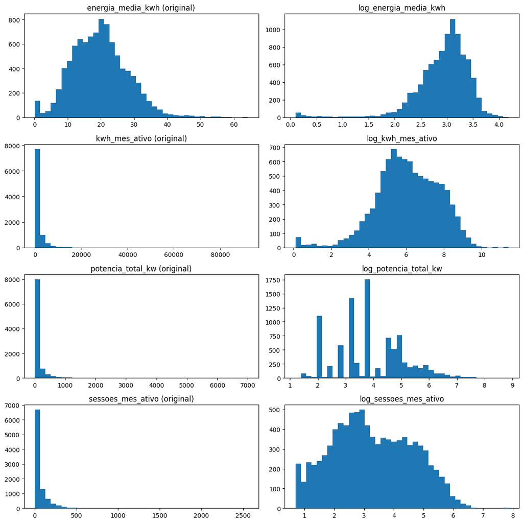

```python
# -------------------------------------------------------------------------------------
# Histograma comparativo entre as features originais e após o skewness
# -------------------------------------------------------------------------------------

fig, axes = plt.subplots(
    nrows=4,
    ncols=2,
    figsize=(12, 12)
)

for i, col in enumerate(variaveis_demo):

    axes[i, 0].hist(
        df_features[col],
        bins=40
    )

    axes[i, 0].set_title(
        f"{col} (original)"
    )

    axes[i, 1].hist(
        df_model[f"log_{col}"],
        bins=40
    )

    axes[i, 1].set_title(
        f"log_{col}"
    )

plt.tight_layout()
plt.show()
```

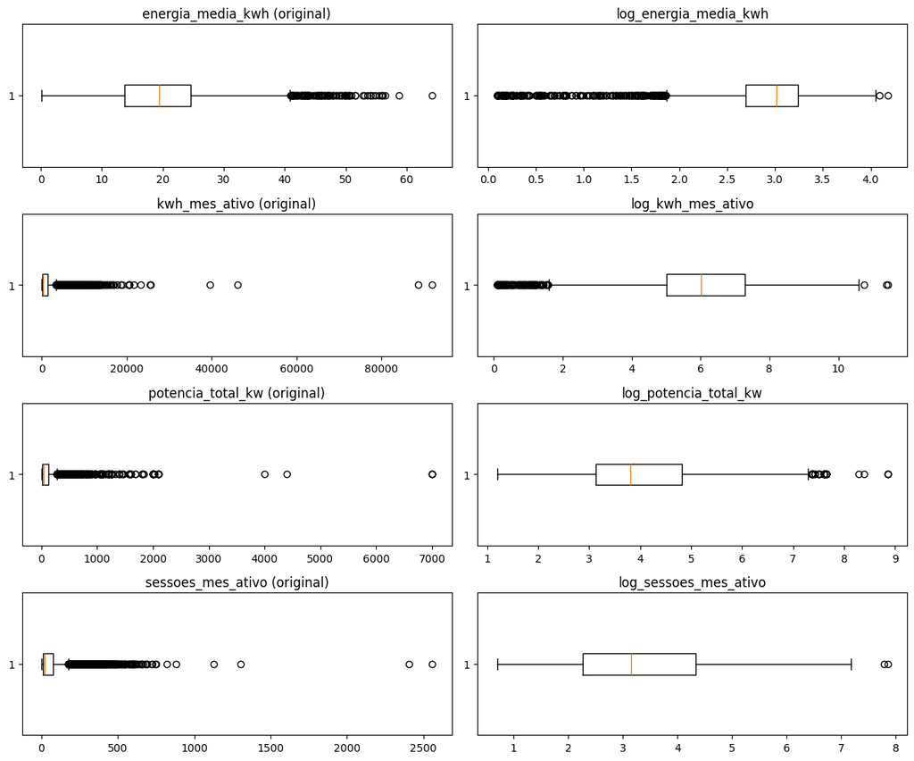

```python
# -----------------------------------------------------------------------------------------
# Boxplot comparativo entre as features originais e após o skewness
# -----------------------------------------------------------------------------------------
fig, axes = plt.subplots(
    nrows=4,
    ncols=2,
    figsize=(12, 10)
)

for i, col in enumerate(variaveis_demo):

    axes[i, 0].boxplot(
        df_features[col],
        vert=False
    )

    axes[i, 0].set_title(
        f"{col} (original)"
    )

    axes[i, 1].boxplot(
        df_model[f"log_{col}"],
        vert=False
    )

    axes[i, 1].set_title(
        f"log_{col}"
    )

plt.tight_layout()
plt.show()
```

## 4.4 Redução de dimensionalidade (PCA)

### 4.4.1 Standardização das variáveis

```python
# ---------------------------------------------
# Algoritmo StandardSacaler (Standardize)
# ---------------------------------------------

from sklearn.preprocessing import StandardScaler, MinMaxScaler, RobustScaler

X = df_model[model_features].copy()

scaler = StandardScaler()
# scaler = MinMaxScaler()
# scaler = RobustScaler() # dificuldade em separar os clusters
X_scaled = scaler.fit_transform(X)

X_scaled.shape
```

```
(9309, 17)
```

```python
# Validar o StandardScaler
X_scaled.mean(axis=0)
```

```
array([-1.70976015e-16,  1.70976015e-16, -4.45758898e-16,  1.34338298e-16,
        1.83188588e-17,  9.77005803e-17,  1.55710300e-16,  1.16019439e-16,
        6.10628627e-18, -2.19826306e-16, -2.32038878e-16,  1.22125725e-16,
       -8.54880077e-17, -4.88502901e-17,  6.10628627e-17,  4.88502901e-17,
       -3.60270890e-16])
```

```python
# Validar o StandardScaler
X_scaled.std(axis=0)
```

```
array([1., 1., 1., 1., 1., 1., 1., 1., 1., 1., 1., 1., 1., 1., 1., 1., 1.])
```

### 4.4.2 Análise da variância explicada

```python
from sklearn.decomposition import PCA

pca = PCA()

X_pca_full = pca.fit_transform(X_scaled)

loadings = pd.DataFrame(
    pca.components_.T,
    index=model_features,
    columns=[f"PC{i+1}" for i in range(len(model_features))]
)
```

```python
# ---------------------------------------------
# Quadro da variância - critério de Kaiser
# ---------------------------------------------

explained = pd.DataFrame({
    "PC": range(
        1,
        len(pca.explained_variance_ratio_) + 1
    ),
    "variance":
        pca.explained_variance_ratio_,
    "cumulative":
        pca.explained_variance_ratio_.cumsum()
})

explained

# explained.head(20)
```

|  | PC | variance | cumulative |
| --- | --- | --- | --- |
| 0 | 1 | 0.384459 | 0.384459 |
| 1 | 2 | 0.184823 | 0.569282 |
| 2 | 3 | 0.117395 | 0.686677 |
| 3 | 4 | 0.085018 | 0.771696 |
| 4 | 5 | 0.066653 | 0.838349 |
| 5 | 6 | 0.049988 | 0.888338 |
| 6 | 7 | 0.032855 | 0.921193 |
| 7 | 8 | 0.023626 | 0.944818 |
| 8 | 9 | 0.021280 | 0.966098 |
| 9 | 10 | 0.011535 | 0.977633 |
| 10 | 11 | 0.007592 | 0.985225 |
| 11 | 12 | 0.005808 | 0.991033 |
| 12 | 13 | 0.003528 | 0.994562 |
| 13 | 14 | 0.003113 | 0.997674 |
| 14 | 15 | 0.001988 | 0.999662 |
| 15 | 16 | 0.000286 | 0.999948 |
| 16 | 17 | 0.000052 | 1.000000 |

```
   PC  eigenvalue  kaiser_ok
0   1    6.536512       True
1   2    3.142325       True
2   3    1.995932       True
3   4    1.445470       True
4   5    1.133231       True
5   6    0.849892      False
6   7    0.558593      False
7   8    0.401684      False
8   9    0.361798      False
9  10    0.196110      False
```

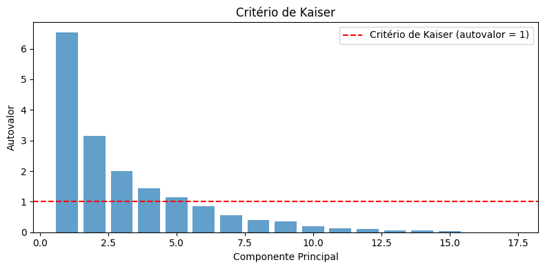

```python
# ------------------------------------------------------------------------------------------
# Critério de Kaiser (autovalores, não variância normalizada)
# ------------------------------------------------------------------------------------------
eigenvalues = pd.DataFrame({
    "PC": range(1, len(pca.explained_variance_) + 1),
    "eigenvalue": pca.explained_variance_
})
eigenvalues["kaiser_ok"] = eigenvalues["eigenvalue"] > 1
print(eigenvalues.head(10))

fig, ax = plt.subplots(figsize=(8, 4))
ax.bar(eigenvalues["PC"], eigenvalues["eigenvalue"], color="#1f77b4", alpha=0.7)
ax.axhline(y=1, color="red", linestyle="--", label="Critério de Kaiser (autovalor = 1)")
ax.set_xlabel("Componente Principal")
ax.set_ylabel("Autovalor")
ax.set_title("Critério de Kaiser")
ax.legend()
plt.tight_layout()
plt.show()
```

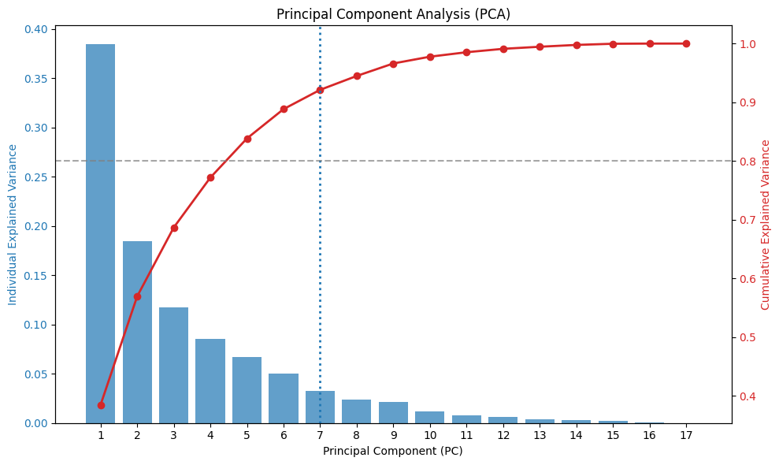

```python
import matplotlib.pyplot as plt

fig, ax1 = plt.subplots(figsize=(10, 6))

# 1. Barras para a variância individual
color_bar = '#1f77b4'
ax1.set_xlabel('Principal Component (PC)')
ax1.set_ylabel('Individual Explained Variance', color=color_bar)
bars = ax1.bar(explained['PC'], explained['variance'], color=color_bar, alpha=0.7, label='Individual')
ax1.tick_params(axis='y', labelcolor=color_bar)
ax1.set_xticks(explained['PC'])

# 2. Linha para a variância acumulada (eixo secundário)
ax2 = ax1.twinx()
color_line = '#d62728'
ax2.set_ylabel('Cumulative Explained Variance', color=color_line)
line = ax2.plot(explained['PC'], explained['cumulative'], color=color_line, marker='o', linewidth=2, label='Acumulada')
ax2.tick_params(axis='y', labelcolor=color_line)

# Variância acumulada
n_components = 7

ax2.axvline(x=n_components,
    linestyle=":",
    linewidth=2
)

# Adiciona a linha guia nos 80% de variância acumulada
ax2.axhline(y=0.80, color='gray', linestyle='--', alpha=0.7, label='Alvo de 80%')

plt.title('Principal Component Analysis (PCA)')

fig.savefig(
    FIG_DIR / f"pca_cumulatice_NB04_4_3_3_02.png",
    dpi=300,
    bbox_inches="tight"
)
fig.tight_layout()
plt.show()
```

# Análise ao número de componentes PCA a escolher

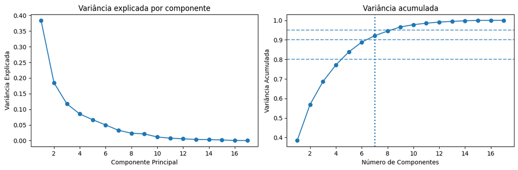

```python
# ------------------------------------------------------------------------------------------
# Plot variância para identificar o número de componentes PCA
# ------------------------------------------------------------------------------------------
"""
    Scree Plot - importância individual de cada componente
    Variância Acumulada - quantas componentes são necessárias para atingir um determinado nível de explicação
"""

fig, axes = plt.subplots(
    nrows=1,
    ncols=2,
    figsize=(12, 4)
)

# Scree Plot
axes[0].plot(
    explained["PC"],
    explained["variance"],
    marker="o"
)

axes[0].set_title("Variância explicada por componente")
axes[0].set_xlabel("Componente Principal")
axes[0].set_ylabel("Variância Explicada")

# Variância acumulada
n_components = 7

axes[1].axvline(
    x=n_components,
    linestyle=":",
    linewidth=2
)

axes[1].plot(
    explained["PC"],
    explained["cumulative"],
    marker="o"
)

axes[1].axhline(
    y=0.80,
    linestyle="--",
    alpha=0.7
)

axes[1].axhline(
    y=0.90,
    linestyle="--",
    alpha=0.7
)

axes[1].axhline(
    y=0.95,
    linestyle="--",
    alpha=0.7
)

axes[1].set_title("Variância acumulada")
axes[1].set_xlabel("Número de Componentes")
axes[1].set_ylabel("Variância Acumulada")

plt.tight_layout()
plt.show()
```

```python
# ---------------------------------------------
# Interpretar componentes PCA (17 features)
# ---------------------------------------------
"""
loadings = pd.DataFrame(
    pca.components_.T,
    index=model_features,
    columns=[f"PC{i+1}" for i in range(len(model_features))]
)
"""
loadings
```

|  | PC1 | PC2 | PC3 | PC4 | PC5 | PC6 | PC7 | PC8 | PC9 | PC10 | PC11 | PC12 | PC13 | PC14 | PC15 | PC16 | PC17 |
| --- | --- | --- | --- | --- | --- | --- | --- | --- | --- | --- | --- | --- | --- | --- | --- | --- | --- |
| log_sessoes_mes_ativo | 0.327927 | 0.173788 | -0.182205 | -0.196032 | 0.112187 | -0.166525 | -0.046615 | 0.043606 | 0.155367 | -0.027994 | 0.125053 | 0.530429 | 0.109556 | -0.128484 | 0.019008 | -0.092551 | -6.220047e-01 |
| log_kwh_mes_ativo | 0.331462 | 0.239717 | -0.069988 | -0.193312 | 0.051785 | 0.090069 | 0.075753 | 0.018571 | 0.085655 | 0.026553 | 0.019133 | 0.452446 | 0.049382 | -0.107875 | 0.016854 | 0.059158 | 7.365791e-01 |
| log_energia_media_kwh | 0.154381 | 0.246154 | 0.269867 | -0.064301 | -0.147970 | 0.677393 | 0.321329 | -0.053147 | -0.156852 | 0.205952 | -0.282979 | 0.039020 | -0.135055 | -0.023071 | -0.002327 | 0.137203 | -2.560434e-01 |
| log_duracao_media_min | -0.277014 | 0.287331 | 0.044934 | -0.028233 | 0.097152 | 0.393108 | 0.041545 | -0.023240 | 0.053116 | -0.295573 | 0.739768 | -0.052445 | 0.149731 | 0.066125 | 0.029457 | -0.060930 | -9.238022e-03 |
| pct_fim_semana | 0.106616 | 0.179173 | 0.341543 | 0.284109 | 0.214833 | -0.454885 | 0.613398 | -0.199295 | -0.190861 | 0.125540 | 0.193895 | -0.004882 | 0.007620 | 0.006434 | -0.007107 | -0.012419 | 4.092715e-04 |
| pct_periodo_descanso | -0.032180 | 0.351919 | 0.414517 | 0.107750 | 0.001849 | -0.103565 | -0.502764 | 0.166609 | 0.198429 | 0.578804 | 0.144568 | -0.041606 | -0.050592 | 0.003209 | 0.006144 | 0.027339 | 7.042043e-03 |
| pct_horario_laboral | 0.020402 | -0.417909 | -0.369717 | -0.129957 | -0.065769 | 0.112587 | 0.219249 | 0.026216 | -0.059493 | 0.664736 | 0.399117 | -0.010279 | -0.022887 | 0.007431 | -0.002833 | 0.012756 | 5.801694e-03 |
| pct_verao | 0.049020 | 0.147165 | -0.257441 | 0.585619 | -0.277211 | 0.031449 | 0.192548 | 0.662780 | 0.082645 | -0.050900 | -0.000178 | 0.048626 | 0.025459 | 0.005285 | 0.007036 | -0.004050 | 6.377653e-07 |
| pct_inverno | -0.031475 | -0.181899 | 0.332329 | -0.506315 | 0.273448 | -0.064848 | 0.220558 | 0.667762 | 0.063342 | -0.074812 | -0.017718 | -0.119695 | -0.008592 | 0.035329 | -0.002860 | 0.000762 | -3.686089e-03 |
| log_n_evse_instalados | 0.268856 | -0.137774 | -0.041396 | 0.255565 | 0.518268 | 0.199197 | -0.127895 | 0.028172 | -0.044572 | -0.003164 | -0.010164 | -0.192490 | 0.017297 | -0.328115 | 0.607530 | -0.008490 | 5.461214e-06 |
| log_n_conectores_instalados | 0.283313 | -0.146706 | -0.015867 | 0.243504 | 0.473212 | 0.185615 | -0.161971 | 0.034043 | -0.088634 | -0.002234 | -0.004882 | 0.000098 | 0.212035 | 0.331703 | -0.593112 | 0.194983 | -1.478393e-02 |
| log_potencia_max_kw | 0.315051 | -0.135557 | 0.184180 | -0.028773 | -0.317725 | 0.016805 | 0.102843 | -0.116974 | 0.415921 | -0.003040 | -0.002968 | -0.285504 | 0.680376 | -0.056190 | 0.037520 | 0.010794 | -3.429499e-03 |
| log_potencia_total_kw | 0.341240 | -0.160607 | 0.110336 | 0.090065 | -0.027167 | 0.094740 | 0.058293 | -0.100394 | 0.472630 | -0.108592 | 0.116139 | -0.099092 | -0.561194 | 0.160206 | -0.107901 | -0.450410 | 2.622673e-02 |
| tem_dc | 0.334925 | -0.094268 | 0.143092 | -0.045546 | -0.264701 | -0.053200 | -0.176442 | 0.064156 | -0.419642 | -0.090428 | 0.149534 | 0.084997 | 0.022892 | 0.616004 | 0.392367 | -0.021117 | 6.132400e-04 |
| tem_rapido | 0.331176 | -0.090223 | 0.145347 | -0.035684 | -0.275488 | -0.044978 | -0.185729 | 0.089958 | -0.425159 | -0.156897 | 0.269334 | -0.157729 | -0.131471 | -0.565715 | -0.314760 | 0.008682 | 3.934380e-03 |
| log_sessoes_por_conector_instalado | 0.245070 | 0.313845 | -0.305282 | -0.188167 | -0.003408 | -0.162796 | 0.044952 | -0.030042 | 0.170960 | -0.068506 | 0.087381 | -0.419167 | -0.269177 | 0.115870 | 0.047857 | 0.612590 | -5.201738e-02 |
| log_kwh_por_kw_instalado | 0.125105 | 0.428532 | -0.319860 | -0.196078 | 0.105384 | -0.022356 | 0.008792 | 0.047082 | -0.242110 | 0.136352 | -0.149659 | -0.393605 | 0.166321 | 0.078347 | -0.095323 | -0.589451 | 3.436520e-02 |

```python
# ---------------------------------------------
# PCA com 7 componentes para o Clustering
# ---------------------------------------------

from sklearn.decomposition import PCA

pca_final = PCA(
    n_components=7,
    random_state=42
)

X_pca = pca_final.fit_transform(X_scaled)

X_pca.shape
```

```
(9309, 7)
```

```python
pca_final.components_.T
```

```
array([[ 0.32792675,  0.17378822, -0.18220456, -0.19603243,  0.11218699,
        -0.16652513, -0.04661517],
       [ 0.33146201,  0.23971715, -0.06998847, -0.19331156,  0.05178496,
         0.09006895,  0.07575349],
       [ 0.15438149,  0.24615366,  0.26986697, -0.06430132, -0.14796994,
         0.67739277,  0.32132894],
       [-0.2770143 ,  0.28733088,  0.04493368, -0.02823296,  0.09715209,
         0.39310817,  0.04154519],
       [ 0.10661645,  0.17917307,  0.34154276,  0.2841094 ,  0.21483308,
        -0.45488462,  0.61339783],
       [-0.03218021,  0.35191911,  0.41451714,  0.10774967,  0.00184853,
        -0.10356503, -0.5027636 ],
       [ 0.02040162, -0.41790919, -0.36971748, -0.12995675, -0.0657692 ,
         0.11258688,  0.21924899],
       [ 0.0490203 ,  0.14716509, -0.25744078,  0.58561909, -0.2772109 ,
         0.03144909,  0.19254775],
       [-0.031475  , -0.18189868,  0.33232919, -0.50631531,  0.27344791,
        -0.06484825,  0.2205579 ],
       [ 0.26885565, -0.13777435, -0.04139593,  0.25556516,  0.51826832,
         0.19919724, -0.12789542],
       [ 0.28331253, -0.1467065 , -0.01586747,  0.24350381,  0.47321158,
         0.18561508, -0.16197111],
       [ 0.31505075, -0.13555666,  0.18417964, -0.02877296, -0.31772518,
         0.01680463,  0.10284264],
       [ 0.34124011, -0.16060693,  0.11033634,  0.09006541, -0.02716723,
         0.09473989,  0.05829313],
       [ 0.33492492, -0.0942683 ,  0.14309214, -0.04554632, -0.26470147,
        -0.05319956, -0.17644179],
       [ 0.33117599, -0.09022299,  0.14534677, -0.03568388, -0.27548848,
        -0.04497773, -0.18572892],
       [ 0.24506987,  0.31384467, -0.3052825 , -0.1881669 , -0.00340765,
        -0.16279604,  0.04495163],
       [ 0.12510506,  0.42853227, -0.31986001, -0.19607766,  0.10538441,
        -0.02235643,  0.00879211]])
```

### 4.4.4 Interpretação das componentes (loadings)

```python
# ---------------------------------------------
# Interpretar componentes PCA
# ---------------------------------------------
loadings_final = pd.DataFrame(
    pca_final.components_.T,
    index=model_features,
    columns=[f"PC{i+1}" for i in range(pca_final.n_components)]
)

loadings_final.head(20)
```

|  | PC1 | PC2 | PC3 | PC4 | PC5 | PC6 | PC7 |
| --- | --- | --- | --- | --- | --- | --- | --- |
| log_sessoes_mes_ativo | 0.327927 | 0.173788 | -0.182205 | -0.196032 | 0.112187 | -0.166525 | -0.046615 |
| log_kwh_mes_ativo | 0.331462 | 0.239717 | -0.069988 | -0.193312 | 0.051785 | 0.090069 | 0.075753 |
| log_energia_media_kwh | 0.154381 | 0.246154 | 0.269867 | -0.064301 | -0.147970 | 0.677393 | 0.321329 |
| log_duracao_media_min | -0.277014 | 0.287331 | 0.044934 | -0.028233 | 0.097152 | 0.393108 | 0.041545 |
| pct_fim_semana | 0.106616 | 0.179173 | 0.341543 | 0.284109 | 0.214833 | -0.454885 | 0.613398 |
| pct_periodo_descanso | -0.032180 | 0.351919 | 0.414517 | 0.107750 | 0.001849 | -0.103565 | -0.502764 |
| pct_horario_laboral | 0.020402 | -0.417909 | -0.369717 | -0.129957 | -0.065769 | 0.112587 | 0.219249 |
| pct_verao | 0.049020 | 0.147165 | -0.257441 | 0.585619 | -0.277211 | 0.031449 | 0.192548 |
| pct_inverno | -0.031475 | -0.181899 | 0.332329 | -0.506315 | 0.273448 | -0.064848 | 0.220558 |
| log_n_evse_instalados | 0.268856 | -0.137774 | -0.041396 | 0.255565 | 0.518268 | 0.199197 | -0.127895 |
| log_n_conectores_instalados | 0.283313 | -0.146706 | -0.015867 | 0.243504 | 0.473212 | 0.185615 | -0.161971 |
| log_potencia_max_kw | 0.315051 | -0.135557 | 0.184180 | -0.028773 | -0.317725 | 0.016805 | 0.102843 |
| log_potencia_total_kw | 0.341240 | -0.160607 | 0.110336 | 0.090065 | -0.027167 | 0.094740 | 0.058293 |
| tem_dc | 0.334925 | -0.094268 | 0.143092 | -0.045546 | -0.264701 | -0.053200 | -0.176442 |
| tem_rapido | 0.331176 | -0.090223 | 0.145347 | -0.035684 | -0.275488 | -0.044978 | -0.185729 |
| log_sessoes_por_conector_instalado | 0.245070 | 0.313845 | -0.305282 | -0.188167 | -0.003408 | -0.162796 | 0.044952 |
| log_kwh_por_kw_instalado | 0.125105 | 0.428532 | -0.319860 | -0.196078 | 0.105384 | -0.022356 | 0.008792 |

### 4.4.5 Visualização dos componentes principais

```python
for pc in ["PC1", "PC2", "PC3", "PC4", "PC5", "PC6", "PC7"]:

    display(
        loadings[[pc]]
        .sort_values(
            by=pc,
            key=abs,
            ascending=False
        )
        .head(5)
    )
```

|  | PC1 |
| --- | --- |
| log_potencia_total_kw | 0.341240 |
| tem_dc | 0.334925 |
| log_kwh_mes_ativo | 0.331462 |
| tem_rapido | 0.331176 |
| log_sessoes_mes_ativo | 0.327927 |

|  | PC2 |
| --- | --- |
| log_kwh_por_kw_instalado | 0.428532 |
| pct_horario_laboral | -0.417909 |
| pct_periodo_descanso | 0.351919 |
| log_sessoes_por_conector_instalado | 0.313845 |
| log_duracao_media_min | 0.287331 |

|  | PC3 |
| --- | --- |
| pct_periodo_descanso | 0.414517 |
| pct_horario_laboral | -0.369717 |
| pct_fim_semana | 0.341543 |
| pct_inverno | 0.332329 |
| log_kwh_por_kw_instalado | -0.319860 |

|  | PC4 |
| --- | --- |
| pct_verao | 0.585619 |
| pct_inverno | -0.506315 |
| pct_fim_semana | 0.284109 |
| log_n_evse_instalados | 0.255565 |
| log_n_conectores_instalados | 0.243504 |

|  | PC5 |
| --- | --- |
| log_n_evse_instalados | 0.518268 |
| log_n_conectores_instalados | 0.473212 |
| log_potencia_max_kw | -0.317725 |
| pct_verao | -0.277211 |
| tem_rapido | -0.275488 |

|  | PC6 |
| --- | --- |
| log_energia_media_kwh | 0.677393 |
| pct_fim_semana | -0.454885 |
| log_duracao_media_min | 0.393108 |
| log_n_evse_instalados | 0.199197 |
| log_n_conectores_instalados | 0.185615 |

|  | PC7 |
| --- | --- |
| pct_fim_semana | 0.613398 |
| pct_periodo_descanso | -0.502764 |
| log_energia_media_kwh | 0.321329 |
| pct_inverno | 0.220558 |
| pct_horario_laboral | 0.219249 |

```python
# -------------------------------------------------------
# Matriz de contribuição de cada feature para as 7 PCA
# -------------------------------------------------------

import numpy as np
import pandas as pd

# Extrair os loadings (pesos) do PCA para as 7 componentes PCA
loadings = pca.components_[:7, :]

# Calcular a contribuição percentual
contribuicoes = (loadings ** 2) / np.sum(loadings ** 2, axis=1)[:, None] * 100

# Usar apenas as colunas que correspondem ao número de variáveis do X_scaled
# Se o X_scaled vier do dataframe, usa-as, caso contrário (se já tiver aplicado StandardScaler) vai ao array que tem as features e faz o cruzamento para associar o nome das colunas
if hasattr(X_scaled, 'columns'):
    nomes_features = X_scaled.columns
else:
    nomes_features = df_features.select_dtypes(include=[np.number]).columns[-17:]

# Criar o DataFrame para as 17 features x 7 componentes (17 linhas, 7 colunas)
df_pca_percent = pd.DataFrame(
    contribuicoes.T,
    columns=[f'PC{i+1}' for i in range(7)],
    index=nomes_features
)

print("--- Contribuição (%) de cada Feature nas Componentes PCA ---")
display(df_pca_percent.style.background_gradient(cmap='Blues', axis=0).format("{:.2f}%"))
```

```
--- Contribuição (%) de cada Feature nas Componentes PCA ---
```

|  | PC1 | PC2 | PC3 | PC4 | PC5 | PC6 | PC7 |
| --- | --- | --- | --- | --- | --- | --- | --- |
| sessoes_mes_ativo | 10.75% | 3.02% | 3.32% | 3.84% | 1.26% | 2.77% | 0.22% |
| kwh_mes_ativo | 10.99% | 5.75% | 0.49% | 3.74% | 0.27% | 0.81% | 0.57% |
| energia_media_kwh | 2.38% | 6.06% | 7.28% | 0.41% | 2.19% | 45.89% | 10.33% |
| duracao_media_min | 7.67% | 8.26% | 0.20% | 0.08% | 0.94% | 15.45% | 0.17% |
| pct_fim_semana | 1.14% | 3.21% | 11.67% | 8.07% | 4.62% | 20.69% | 37.63% |
| pct_periodo_descanso | 0.10% | 12.38% | 17.18% | 1.16% | 0.00% | 1.07% | 25.28% |
| pct_horario_laboral | 0.04% | 17.46% | 13.67% | 1.69% | 0.43% | 1.27% | 4.81% |
| pct_verao | 0.24% | 2.17% | 6.63% | 34.29% | 7.68% | 0.10% | 3.71% |
| pct_inverno | 0.10% | 3.31% | 11.04% | 25.64% | 7.48% | 0.42% | 4.86% |
| n_evse_instalados | 7.23% | 1.90% | 0.17% | 6.53% | 26.86% | 3.97% | 1.64% |
| n_conectores_instalados | 8.03% | 2.15% | 0.03% | 5.93% | 22.39% | 3.45% | 2.62% |
| potencia_max_kw | 9.93% | 1.84% | 3.39% | 0.08% | 10.09% | 0.03% | 1.06% |
| potencia_total_kw | 11.64% | 2.58% | 1.22% | 0.81% | 0.07% | 0.90% | 0.34% |
| tem_dc | 11.22% | 0.89% | 2.05% | 0.21% | 7.01% | 0.28% | 3.11% |
| tem_rapido | 10.97% | 0.81% | 2.11% | 0.13% | 7.59% | 0.20% | 3.45% |
| sessoes_por_conector_instalado | 6.01% | 9.85% | 9.32% | 3.54% | 0.00% | 2.65% | 0.20% |
| kwh_por_kw_instalado | 1.57% | 18.36% | 10.23% | 3.84% | 1.11% | 0.05% | 0.01% |

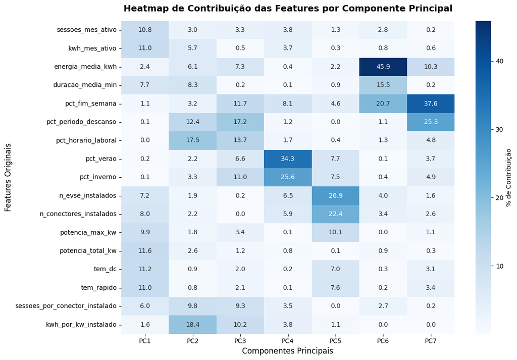

```python
# ---------------------------------------------
# Plot heatmap com as contribuições PCA
# ---------------------------------------------
plt.figure(figsize=(12, 8))
sns.heatmap(df_pca_percent, annot=True, fmt=".1f", cmap="Blues", cbar_kws={'label': '% de Contribuição'})
plt.title("Heatmap de Contribuição das Features por Componente Principal", fontsize=14, fontweight='bold', pad=15)
plt.xlabel("Componentes Principais", fontsize=12)
plt.ylabel("Features Originais", fontsize=12)
plt.tight_layout()
plt.show()
```

## 4.5 Agrupamento K-Means

### 4.5.1 Seleção do número de clusters

Calcular o número de clusters: Elbow (SSE) Calinski-Harabasz Davies-Bouldin

|  | k | inertia | silhouette | calinski_harabasz | davies_bouldin |
| --- | --- | --- | --- | --- | --- |
| 0 | 2 | 97850.903454 | 0.337506 | 4558.886352 | 1.088724 |
| 1 | 3 | 82172.435580 | 0.294094 | 3601.885761 | 1.519161 |
| 2 | 4 | 68747.612465 | 0.290577 | 3475.519553 | 1.352893 |
| 3 | 5 | 61866.726114 | 0.278478 | 3154.942017 | 1.364592 |
| 4 | 6 | 56646.587760 | 0.284886 | 2927.709327 | 1.325080 |
| 5 | 7 | 52288.362935 | 0.287998 | 2772.042904 | 1.288401 |
| 6 | 8 | 48826.383220 | 0.281609 | 2638.444404 | 1.304657 |
| 7 | 9 | 46766.062624 | 0.269731 | 2461.302338 | 1.379961 |
| 8 | 10 | 44867.470807 | 0.267943 | 2323.895448 | 1.374248 |

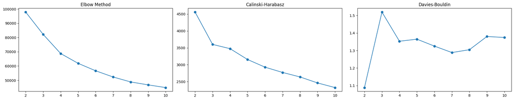

```python
# ------------------------------------------------------------------------------------------
# Plot :: Método Elbow (SSE - Inertia) + Calinski-Harabasz Davies-Bouldin
# ------------------------------------------------------------------------------------------

from sklearn.cluster import KMeans
from sklearn.metrics import silhouette_score, calinski_harabasz_score, davies_bouldin_score


k_range =range(2, 11)
results_raw =[]
labels_kmeans = {}
models_kmeans = {}

for k in k_range:
    km = KMeans(n_clusters=k, random_state=42, n_init=20)
    labels = km.fit_predict(X_pca)

    # guradar na labels e no model o modelo treinado para cada k (labels e modelo)
    models_kmeans[k] = km
    labels_kmeans[k] = labels.copy()


    results_raw.append({
        "k": k,
        "inertia": km.inertia_,
        "silhouette": silhouette_score(X_pca, labels),
        "calinski_harabasz": calinski_harabasz_score(X_pca, labels),
        "davies_bouldin": davies_bouldin_score(X_pca, labels)
    })


results_raw_df = pd.DataFrame(results_raw)
# print(results_raw_df)
display(results_raw_df)

fig, axes = plt.subplots(1, 3, figsize=(20, 4))
axes[0].plot(results_raw_df["k"], results_raw_df["inertia"], marker="o")
axes[0].set_title("Elbow Method")
axes[1].plot(results_raw_df["k"], results_raw_df["calinski_harabasz"], marker="o")
axes[1].set_title("Calinski-Harabasz")
axes[2].plot(results_raw_df["k"], results_raw_df["davies_bouldin"], marker="o")
axes[2].set_title("Davies-Bouldin")
plt.tight_layout()
fig.savefig(
    FIG_DIR / f"elbow_ch_db_method_NB04_4_3_3_03.png",
    dpi=300,
    bbox_inches="tight"
)
plt.show()
```

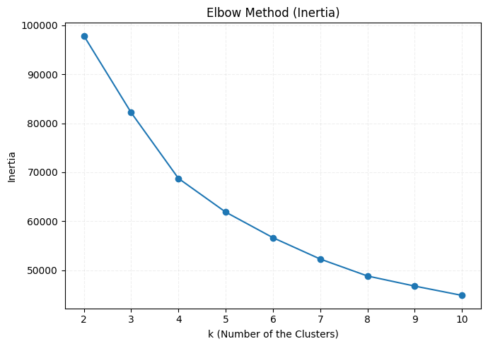

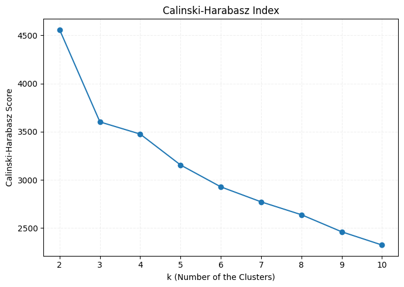

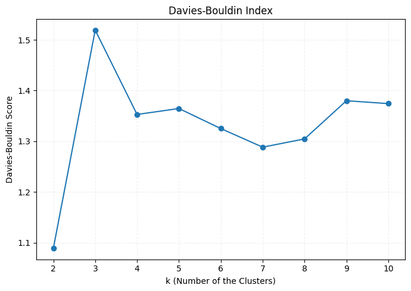

```python
# ---------------------------------------------
# 1. Método Elbow (Inertia)
# ---------------------------------------------

fig, ax = plt.subplots(figsize=(7, 5))
ax.plot(
    results_raw_df["k"], results_raw_df["inertia"], marker="o", color="tab:blue"
)
ax.set_title("Elbow Method (Inertia)")
ax.set_xlabel("k (Number of the Clusters)")
ax.set_ylabel("Inertia")
ax.grid(True, linestyle="--", alpha=0.2)
plt.tight_layout()
fig.savefig(
    FIG_DIR / "elbow_method_NB04_4_4_3_17.png", dpi=300, bbox_inches="tight"
)
plt.show()

# ---------------------------------------------
# 2. Calinski-Harabasz Score
# ---------------------------------------------
fig, ax = plt.subplots(figsize=(7, 5))
ax.plot(
    results_raw_df["k"],
    results_raw_df["calinski_harabasz"],
    marker="o",
    #color="tab:orange",
)
ax.set_title("Calinski-Harabasz Index")
ax.set_xlabel("k (Number of the Clusters)")
ax.set_ylabel("Calinski-Harabasz Score")
ax.grid(True, linestyle="--", alpha=0.2)
plt.tight_layout()
fig.savefig(
    FIG_DIR / "calinski_harabasz_NB04_4_4_3_17.png",
    dpi=300,
    bbox_inches="tight",
)
plt.show()

# ---------------------------------------------
# 3. Davies-Bouldin Score
# ---------------------------------------------
fig, ax = plt.subplots(figsize=(7, 5))
ax.plot(
    results_raw_df["k"],
    results_raw_df["davies_bouldin"],
    marker="o",
    #color="tab:green",
)
ax.set_title("Davies-Bouldin Index")
ax.set_xlabel("k (Number of the Clusters)")
ax.set_ylabel("Davies-Bouldin Score")
ax.grid(True, linestyle="--", alpha=0.2)
plt.tight_layout()
fig.savefig(
    FIG_DIR / "davies_bouldin_NB044_4_4_3_17.png", dpi=300, bbox_inches="tight"
)
plt.show()
```

```python
df_cluster = df_features.copy()

km_range = [4, 5, 6,7]
cluster_sizes = []

# adicionar apenas as labels para k=4 e k=5
for k in km_range:
    if k in labels_kmeans:
        df_cluster[f"cluster_k{k}"] = labels_kmeans[k]

# opcional - adicionar apenas os clusters selecionados às componentes PCA
for i in range(X_pca.shape[1]):
    df_cluster[f"PC{i+1}"] = X_pca[:, i]

for k in km_range:
    print(f"--- k={k} ---")
    print(df_cluster[f"cluster_k{k}"].value_counts().sort_index().to_string())
    print()
```

```
--- k=4 ---
cluster_k4
0    3636
1    2598
2    1195
3    1880

--- k=5 ---
cluster_k5
0    1802
1    2683
2    2578
3     563
4    1683

--- k=6 ---
cluster_k6
0    2069
1    1584
2    1619
3    2576
4     273
5    1188

--- k=7 ---
cluster_k7
0    2491
1    1492
2    1894
3    1529
4     219
5     510
6    1174
```

```python
print(models_kmeans[4].cluster_centers_)
```

```
[[-0.49672388  0.45357363 -0.97779286 -0.00915742  0.47995785  0.03356683
   0.24882126]
 [ 3.55416697 -0.36170169  0.44169165 -0.09950394 -0.44173295 -0.07595386
  -0.14785353]
 [-2.40596335 -2.94124391 -0.16372471 -0.18922554 -0.0864479   0.11514363
  -0.06661875]
 [-2.42155699  1.49453699  1.38560653  0.27574313 -0.26296586 -0.03322653
  -0.23465386]]
```

# Análise de Silhoute :: Adaptado dos diapositivos da unidade curricular de ML (MEI-ISEC) (prof. Simão Paredes que remete para: https://scikit-learn.org/stable/auto_examples/cluster/plot_kmeans_silhouette_analysis.html)

```
Para k=4, a silhueta média é: 0.291
Para k=5, a silhueta média é: 0.278
Para k=6, a silhueta média é: 0.285
Para k=7, a silhueta média é: 0.288
```

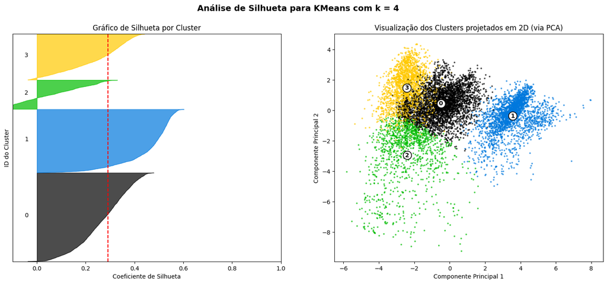

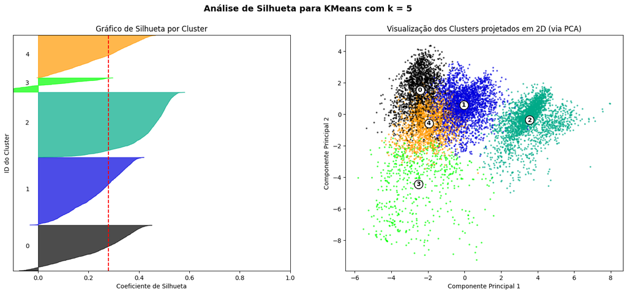

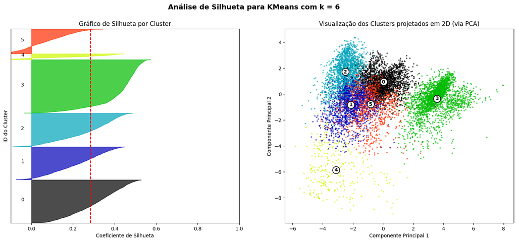

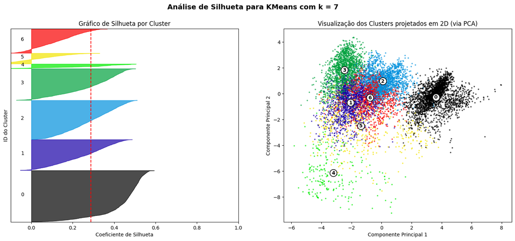

```python
import matplotlib.cm as cm
import matplotlib.pyplot as plt
import numpy as np

from sklearn.metrics import silhouette_samples, silhouette_score


range_n_clusters = [4, 5, 6, 7]

for n_clusters in range_n_clusters:
    fig, (ax1, ax2) = plt.subplots(1, 2)
    fig.set_size_inches(18, 7)

    ax1.set_xlim([-0.1, 1])
    ax1.set_ylim([0, len(X_pca) + (n_clusters + 1) * 10])

    cluster_labels = labels_kmeans[n_clusters]
    clusterer = models_kmeans[n_clusters]

    silhouette_avg = silhouette_score(X_pca, cluster_labels)
    print(f"Para k={n_clusters}, a silhueta média é: {silhouette_avg:.3f}")

    sample_silhouette_values = silhouette_samples(X_pca, cluster_labels)

    y_lower = 10
    for i in range(n_clusters):
        ith_cluster_silhouette_values = sample_silhouette_values[cluster_labels == i]
        ith_cluster_silhouette_values.sort()

        size_cluster_i = ith_cluster_silhouette_values.shape[0]
        y_upper = y_lower + size_cluster_i

        color = cm.nipy_spectral(float(i) / n_clusters)
        ax1.fill_betweenx(
            np.arange(y_lower, y_upper),
            0,
            ith_cluster_silhouette_values,
            facecolor=color,
            edgecolor=color,
            alpha=0.7,
        )
        ax1.text(-0.05, y_lower + 0.5 * size_cluster_i, str(i))
        y_lower = y_upper + 10

    ax1.set_title("Gráfico de Silhueta por Cluster")
    ax1.set_xlabel("Coeficiente de Silhueta")
    ax1.set_ylabel("ID do Cluster")
    ax1.axvline(x=silhouette_avg, color="red", linestyle="--")
    ax1.set_yticks([])

    # 2nd Plot: Visualização 2D usando as coordenadas do PCA
    colors = cm.nipy_spectral(cluster_labels.astype(float) / n_clusters)
    ax2.scatter(
        X_pca[:, 0], X_pca[:, 1], marker=".", s=30, lw=0, alpha=0.7, c=colors, edgecolor="k"
    )

    # Nota: Como o treino foi feito em 17D, calcular os centros diretamente em PCA 2D simplifica o desenho
    # centers_pca = np.array([X_pca[cluster_labels == i].mean(axis=0) for i in range(n_clusters)])
    centers_2d = clusterer.cluster_centers_[:, :2]

    ax2.scatter(
        centers_2d[:, 0],
        centers_2d[:, 1],
        marker="o",
        c="white",
        alpha=1,
        s=200,
        edgecolors="black",
        linewidths=1.2,
        zorder=4
    )

    for cluster_id, center in enumerate(centers_2d):
        ax2.text(center[0],center[1],str(cluster_id),
            ha="center",
            va="center",
            fontsize=10,
            fontweight="bold",
            zorder=5
        )

    ax2.set_title("Visualização dos Clusters projetados em 2D (via PCA)")
    ax2.set_xlabel("Componente Principal 1")
    ax2.set_ylabel("Componente Principal 2")

    plt.suptitle(
        f"Análise de Silhueta para KMeans com k = {n_clusters}",
        fontsize=14,
        fontweight="bold",
    )

plt.show()
```

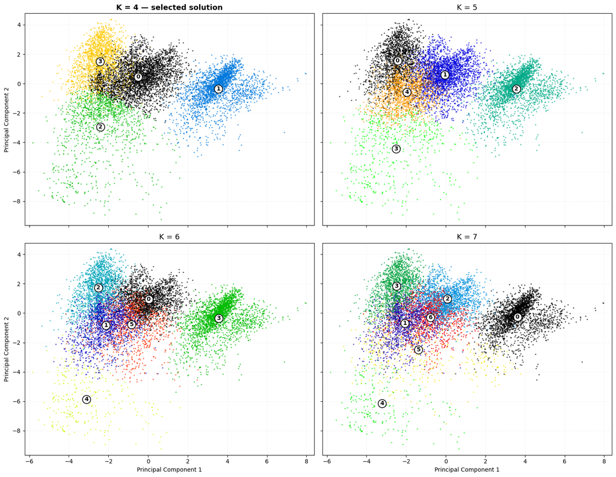

```python
# ---------------------------------------------
# Soluções usadas para comparação (k)
# ---------------------------------------------

k_values = [4, 5, 6, 7]

# Mesma escala em todos os gráficos
x_min, x_max = X_pca[:, 0].min(), X_pca[:, 0].max()
y_min, y_max = X_pca[:, 1].min(), X_pca[:, 1].max()

# Pequena margem visual
x_margin = (x_max - x_min) * 0.03
y_margin = (y_max - y_min) * 0.03

fig, axes = plt.subplots(
    2,
    2,
    figsize=(15, 12),
    sharex=True,
    sharey=True
)

for ax, k in zip(axes.flat, k_values):

    # Resultados já calculados no primeiro ciclo do K-Means
    labels = labels_kmeans[k]
    model = models_kmeans[k]

    # Cores similares ao gráfico de silhueta
    colors = cm.nipy_spectral( labels.astype(float) / k )

    # Projeção dos postos nas duas primeiras componentes
    ax.scatter(
        X_pca[:, 0],
        X_pca[:, 1],
        marker=".",
        s=18,           # 12 pontos ficam ligeiramente mais pequenos
        alpha=0.7,      # 0.65 mais transparente
        c=colors,
        edgecolor="k",
        linewidths=0
    )

    # Centros dos grupos projetados nas duas primeiras componentes
    #
    # Como o K-Means foi treinado sobre X_pca, os centros já estão
    # no espaço PCA. Seleciona-se apenas PC1 e PC2 para o gráfico.
    centers_2d = model.cluster_centers_[:, :2]

    ax.scatter(
        centers_2d[:, 0],
        centers_2d[:, 1],
        marker="o",
        c="white",
        alpha=1,
        s=200,
        edgecolors="black",
        linewidths=1.2,
        zorder=4
    )

    # Identificação numérica dos clusters
    for cluster_id, center in enumerate(centers_2d):
        ax.text(
            center[0],
            center[1],
            str(cluster_id),
            horizontalalignment="center",
            verticalalignment="center",
            fontsize=10,
            fontweight="bold",
            zorder=5
        )

    title = f"K = {k}"

    if k == 4:
        title += " — selected solution"

    ax.set_title(
        title,
        fontsize=13,
        fontweight="bold" if k == 4 else "normal"
    )

    ax.set_xlim(x_min - x_margin, x_max + x_margin)
    ax.set_ylim(y_min - y_margin, y_max + y_margin)

    ax.grid(
        alpha=0.15,
        linestyle="--"
    )

# Eixos necessários
axes[0, 0].set_ylabel("Principal Component 2")
axes[1, 0].set_ylabel("Principal Component 2")

axes[1, 0].set_xlabel("Principal Component 1")
axes[1, 1].set_xlabel("Principal Component 1")

plt.tight_layout(rect=[0, 0, 1, 0.97])

fig.savefig(
    FIG_DIR / "kmeans_clusters_k4_k7_pca.png",
    dpi=300,
    bbox_inches="tight"
)

plt.show()
```

```python
# ---------------------------------------------
# Comparação de métricas
# ---------------------------------------------
from sklearn.metrics import silhouette_score

# Usar apenas os dois candidatos
k_candidatos = [4, 5, 6, 7]

print("--- COMPARAÇÃO DE MÉTRICAS ---")
for k in k_candidatos:
    km = models_kmeans[k]
    labels = labels_kmeans[k]

    row = results_raw_df.loc[
        results_raw_df["k"] == k
    ].iloc[0]

    # Calcular a Silhouette Score (quanto maior for o seu valor, melhor)


    # Usar as métricas que já tinham sido calculadas antes e que estão armazenadas no DataFrame anterior
    sil = row['silhouette']
    inertia = row['inertia']
    db = row['davies_bouldin']
    ch = row['calinski_harabasz']

    print(f"K = {k}:")
    print(f"  - Inércia (Menor é melhor): {inertia:.2f}")
    print(f"  - Davies-Bouldin (Menor é melhor): {db:.4f}")
    print(f"  - Silhouette Score (Maior é melhor): {sil:.4f}")
    print("-" * 30)
```

```
--- COMPARAÇÃO DE MÉTRICAS ---
K = 4:
  - Inércia (Menor é melhor): 68747.61
  - Davies-Bouldin (Menor é melhor): 1.3529
  - Silhouette Score (Maior é melhor): 0.2906
------------------------------
K = 5:
  - Inércia (Menor é melhor): 61866.73
  - Davies-Bouldin (Menor é melhor): 1.3646
  - Silhouette Score (Maior é melhor): 0.2785
------------------------------
K = 6:
  - Inércia (Menor é melhor): 56646.59
  - Davies-Bouldin (Menor é melhor): 1.3251
  - Silhouette Score (Maior é melhor): 0.2849
------------------------------
K = 7:
  - Inércia (Menor é melhor): 52288.36
  - Davies-Bouldin (Menor é melhor): 1.2884
  - Silhouette Score (Maior é melhor): 0.2880
------------------------------
```

```python
# -----------------------------------------------------------------------------------------
# --- CARACTERIZAÇÃO COMPLEMENTAR PARA DECISÃO DE K ---
# -----------------------------------------------------------------------------------------
cluster_summaries = {}

for k_test in [4, 5, 6, 7]:
    print(f"--- QUADRO DE CARACTERIZAÇÃO PARA K = {k_test} ---")

    # Criar um DataFrame temporário cruzando os dados originais com os labels deste K
    df_temp = df_features.copy()
    df_temp["cluster_temp"] = labels_kmeans[k_test]

    # Gerar o resumo das médias
    """cluster_summary_temp = (
        df_temp
        .groupby("cluster_temp")[features]
        .mean()
        .round(2)
    )"""
    # Gerar o resumo das medianas
    cluster_summary_temp = (
        df_temp
        .groupby("cluster_temp")[features]
        #.median()
        .mean()
        .round(2)
    )

    # Adicionar a contagem de postos
    cluster_summary_temp["n_postos"] = (
        df_temp
        .groupby("cluster_temp")
        .size()
    )

    # Guarda o vetor no dicionário (para reusar mais tarde)
    cluster_summaries[k_test] = cluster_summary_temp

    # Apresentar a tabela transposta
    display(cluster_summary_temp.T)

# Criar as variáveis com os k test apara usar na comparação - por exemplo nos centroids
cluster_summary_k4 = cluster_summaries[4]
cluster_summary_k5 = cluster_summaries[5]
```

```
--- QUADRO DE CARACTERIZAÇÃO PARA K = 4 ---
```

| cluster_temp | 0 | 1 | 2 | 3 |
| --- | --- | --- | --- | --- |
| sessoes_mes_ativo | 47.51 | 141.55 | 5.58 | 9.21 |
| kwh_mes_ativo | 741.17 | 3417.58 | 77.88 | 197.77 |
| energia_media_kwh | 16.59 | 24.47 | 13.20 | 22.93 |
| duracao_media_min | 206.68 | 42.65 | 193.97 | 523.44 |
| pct_fim_semana | 0.24 | 0.30 | 0.11 | 0.31 |
| pct_periodo_descanso | 0.24 | 0.31 | 0.11 | 0.62 |
| pct_horario_laboral | 0.44 | 0.43 | 0.66 | 0.20 |
| pct_verao | 0.28 | 0.26 | 0.15 | 0.24 |
| pct_inverno | 0.21 | 0.25 | 0.37 | 0.25 |
| n_evse_instalados | 2.16 | 2.92 | 1.82 | 1.18 |
| n_conectores_instalados | 2.07 | 3.12 | 1.84 | 1.19 |
| potencia_max_kw | 16.57 | 84.44 | 19.07 | 13.69 |
| potencia_total_kw | 48.28 | 288.28 | 48.02 | 20.05 |
| tem_dc | 0.01 | 1.00 | 0.05 | 0.00 |
| tem_rapido | 0.00 | 0.95 | 0.04 | 0.00 |
| sessoes_por_conector_instalado | 440.65 | 684.28 | 23.22 | 82.06 |
| kwh_por_kw_instalado | 421.08 | 237.73 | 18.81 | 158.93 |
| n_postos | 3636.00 | 2598.00 | 1195.00 | 1880.00 |

```
--- QUADRO DE CARACTERIZAÇÃO PARA K = 5 ---
```

| cluster_temp | 0 | 1 | 2 | 3 | 4 |
| --- | --- | --- | --- | --- | --- |
| sessoes_mes_ativo | 9.42 | 57.88 | 141.90 | 3.54 | 14.52 |
| kwh_mes_ativo | 200.92 | 906.73 | 3432.66 | 39.87 | 221.01 |
| energia_media_kwh | 22.94 | 16.89 | 24.53 | 9.62 | 16.33 |
| duracao_media_min | 526.51 | 175.80 | 42.43 | 109.72 | 289.10 |
| pct_fim_semana | 0.32 | 0.30 | 0.30 | 0.13 | 0.08 |
| pct_periodo_descanso | 0.63 | 0.30 | 0.31 | 0.11 | 0.11 |
| pct_horario_laboral | 0.20 | 0.41 | 0.43 | 0.73 | 0.53 |
| pct_verao | 0.23 | 0.29 | 0.25 | 0.12 | 0.23 |
| pct_inverno | 0.26 | 0.21 | 0.25 | 0.44 | 0.23 |
| n_evse_instalados | 1.15 | 2.50 | 2.91 | 2.12 | 1.39 |
| n_conectores_instalados | 1.17 | 2.38 | 3.11 | 2.15 | 1.39 |
| potencia_max_kw | 13.75 | 17.64 | 84.83 | 22.94 | 14.52 |
| potencia_total_kw | 19.62 | 58.89 | 289.30 | 64.72 | 26.11 |
| tem_dc | 0.00 | 0.02 | 1.00 | 0.09 | 0.01 |
| tem_rapido | 0.00 | 0.00 | 0.95 | 0.08 | 0.00 |
| sessoes_por_conector_instalado | 86.02 | 512.08 | 687.11 | 5.07 | 153.80 |
| kwh_por_kw_instalado | 164.95 | 482.67 | 238.20 | 2.65 | 155.73 |
| n_postos | 1802.00 | 2683.00 | 2578.00 | 563.00 | 1683.00 |

```
--- QUADRO DE CARACTERIZAÇÃO PARA K = 6 ---
```

| cluster_temp | 0 | 1 | 2 | 3 | 4 | 5 |
| --- | --- | --- | --- | --- | --- | --- |
| sessoes_mes_ativo | 72.21 | 12.35 | 9.82 | 142.08 | 1.77 | 11.07 |
| kwh_mes_ativo | 1115.01 | 189.34 | 210.91 | 3436.68 | 8.27 | 197.92 |
| energia_media_kwh | 16.23 | 16.36 | 23.26 | 24.52 | 4.41 | 17.89 |
| duracao_media_min | 176.77 | 295.05 | 555.47 | 42.33 | 50.94 | 187.55 |
| pct_fim_semana | 0.28 | 0.06 | 0.30 | 0.30 | 0.04 | 0.35 |
| pct_periodo_descanso | 0.29 | 0.10 | 0.66 | 0.31 | 0.05 | 0.29 |
| pct_horario_laboral | 0.43 | 0.55 | 0.19 | 0.43 | 0.89 | 0.40 |
| pct_verao | 0.27 | 0.21 | 0.22 | 0.25 | 0.16 | 0.29 |
| pct_inverno | 0.22 | 0.26 | 0.26 | 0.25 | 0.37 | 0.24 |
| n_evse_instalados | 2.25 | 1.35 | 1.06 | 2.91 | 1.86 | 2.79 |
| n_conectores_instalados | 2.12 | 1.35 | 1.07 | 3.11 | 1.90 | 2.76 |
| potencia_max_kw | 17.28 | 14.44 | 13.50 | 84.76 | 23.07 | 19.39 |
| potencia_total_kw | 50.75 | 25.20 | 17.30 | 289.25 | 56.87 | 72.39 |
| tem_dc | 0.01 | 0.01 | 0.00 | 1.00 | 0.11 | 0.04 |
| tem_rapido | 0.00 | 0.00 | 0.00 | 0.95 | 0.10 | 0.02 |
| sessoes_por_conector_instalado | 672.09 | 120.37 | 90.84 | 687.90 | 2.29 | 51.38 |
| kwh_por_kw_instalado | 631.03 | 132.43 | 177.02 | 238.62 | 0.70 | 44.67 |
| n_postos | 2069.00 | 1584.00 | 1619.00 | 2576.00 | 273.00 | 1188.00 |

```
--- QUADRO DE CARACTERIZAÇÃO PARA K = 7 ---
```

| cluster_temp | 0 | 1 | 2 | 3 | 4 | 5 | 6 |
| --- | --- | --- | --- | --- | --- | --- | --- |
| sessoes_mes_ativo | 145.94 | 12.85 | 76.47 | 9.98 | 1.62 | 13.52 | 12.31 |
| kwh_mes_ativo | 3528.34 | 195.02 | 1177.86 | 215.17 | 4.61 | 263.07 | 224.45 |
| energia_media_kwh | 24.48 | 16.02 | 16.07 | 23.46 | 2.69 | 18.75 | 18.28 |
| duracao_media_min | 42.21 | 294.13 | 171.65 | 561.11 | 29.70 | 198.10 | 207.49 |
| pct_fim_semana | 0.30 | 0.06 | 0.27 | 0.30 | 0.03 | 0.27 | 0.34 |
| pct_periodo_descanso | 0.31 | 0.09 | 0.29 | 0.67 | 0.04 | 0.26 | 0.31 |
| pct_horario_laboral | 0.43 | 0.55 | 0.43 | 0.18 | 0.91 | 0.49 | 0.39 |
| pct_verao | 0.26 | 0.23 | 0.26 | 0.23 | 0.19 | 0.01 | 0.35 |
| pct_inverno | 0.23 | 0.21 | 0.22 | 0.23 | 0.27 | 0.77 | 0.17 |
| n_evse_instalados | 2.92 | 1.37 | 2.26 | 1.05 | 1.84 | 2.05 | 2.71 |
| n_conectores_instalados | 3.12 | 1.37 | 2.12 | 1.06 | 1.89 | 2.10 | 2.65 |
| potencia_max_kw | 84.10 | 14.34 | 17.35 | 13.32 | 22.94 | 35.10 | 17.99 |
| potencia_total_kw | 287.41 | 25.82 | 51.13 | 17.02 | 57.17 | 101.78 | 66.25 |
| tem_dc | 1.00 | 0.01 | 0.01 | 0.00 | 0.11 | 0.23 | 0.02 |
| tem_rapido | 0.95 | 0.00 | 0.00 | 0.00 | 0.09 | 0.20 | 0.01 |
| sessoes_por_conector_instalado | 710.65 | 133.57 | 716.68 | 95.46 | 2.02 | 14.36 | 69.29 |
| kwh_por_kw_instalado | 246.52 | 145.53 | 670.40 | 187.59 | 0.43 | 11.22 | 65.02 |
| n_postos | 2491.00 | 1492.00 | 1894.00 | 1529.00 | 219.00 | 510.00 | 1174.00 |

```python
# ---------------------------------------------
#   Mapeamento para overleaf (EN)
# ---------------------------------------------
feature_labels_en = {
    "sessoes_mes_ativo": "Sessions per active month",
    "kwh_mes_ativo": "Energy per active month",
    "energia_media_kwh": "Mean energy per session",
    "duracao_media_min": "Mean session duration",
    "pct_fim_semana": "Weekend sessions",
    "pct_periodo_descanso": "Rest-period sessions",
    "pct_horario_laboral": "Working-hours sessions",
    "pct_verao": "Summer sessions",
    "pct_inverno": "Winter sessions",
    "n_evse_instalados": "Installed EVSEs",
    "n_conectores_instalados": "Installed connectors",
    "potencia_max_kw": "Maximum power",
    "potencia_total_kw": "Total installed power",
    "tem_dc": "DC availability",
    "tem_rapido": "Fast-charging availability",
    "sessoes_por_conector_instalado": "Sessions per installed connector",
    "kwh_por_kw_instalado": "Energy per installed kW"
}
```

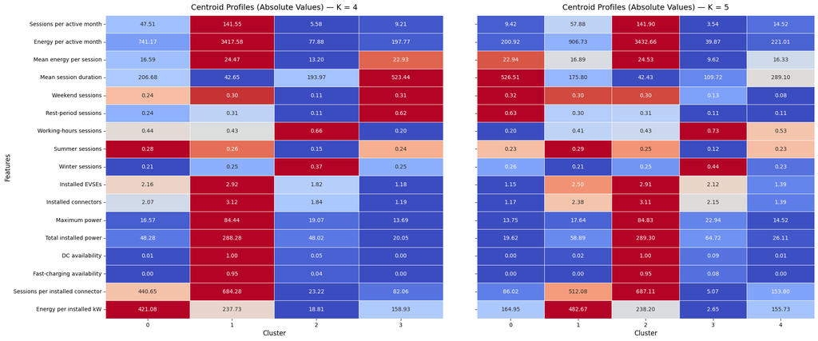

```python
# ---------------------------------------------------
# Criar matriz com os centroids para k=4 e k=5 (EN)
# ---------------------------------------------------

# 1. Preparar os dados para K=4 ('cluster_summary_k4')
features_k4 = [col for col in cluster_summary_k4.columns if col != 'n_postos']

texto_k4 = cluster_summary_k4[features_k4].copy()
texto_k4.index = texto_k4.index

cores_k4 = texto_k4.apply(
    lambda x: (x - x.min()) / (
        x.max() - x.min()
        if (x.max() - x.min()) != 0
        else 1
    ),
    axis=0
)

# nomes em inglês apenas para visualização
texto_k4_plot = texto_k4.rename(columns=feature_labels_en)
cores_k4_plot = cores_k4.rename(columns=feature_labels_en)


# 2. Preparar os dados para K=5 ('cluster_summary_k5')

features_k5 = [col for col in cluster_summary_k5.columns if col != 'n_postos']

texto_k5 = cluster_summary_k5[features_k5].copy()

cores_k5 = texto_k5.apply(
    lambda x: (x - x.min()) / (
        x.max() - x.min()
        if (x.max() - x.min()) != 0
        else 1
    ),
    axis=0
)

# nomes em inglês apenas para visualização
texto_k5_plot = texto_k5.rename(columns=feature_labels_en)
cores_k5_plot = cores_k5.rename(columns=feature_labels_en)

# 3. Desenhar ambos os gráficos lado a lado
fig, axes = plt.subplots(1, 2, figsize=(24, 10))

# Heatmap K=4
sns.heatmap(
    cores_k4_plot.T,
    annot=texto_k4_plot.T,
    fmt=".2f",
    cmap="coolwarm",
    linewidths=0.5,
    cbar=False,
    ax=axes[0]
)

axes[0].set_title( "Centroid Profiles (Absolute Values) — K = 4", fontsize=14, pad=10)
axes[0].set_xlabel("Cluster", fontsize=12)
axes[0].set_ylabel("Features", fontsize=12)


# Heatmap K=5
sns.heatmap(
    cores_k5_plot.T,
    annot=texto_k5_plot.T,
    fmt=".2f",
    cmap="coolwarm",
    linewidths=0.5,
    cbar=False,
    ax=axes[1]
)

axes[1].set_title(
    "Centroid Profiles (Absolute Values) — K = 5",
    fontsize=14,
    pad=10
)

axes[1].set_xlabel("Cluster", fontsize=12)
axes[1].set_ylabel("")
axes[1].set_yticklabels([])

plt.subplots_adjust(left=0.15, wspace=0.1)

fig.savefig(
    FIG_DIR / "centroids_profiles_k4_k5_absolute_values.png",
    dpi=300,
    bbox_inches="tight"
)

plt.show()
```

```python
from sklearn.metrics import silhouette_score

for k_test in [4, 5]:
    # Apanha os labels correspondentes do teu dicionário de modelos
    labels_atuais = labels_kmeans[k_test]

    score = silhouette_score(X_pca, labels_kmeans[k_test])
    print(f"Silhouette Score para K = {k_test}: {score:.3f}")
```

```
Silhouette Score para K = 4: 0.291
Silhouette Score para K = 5: 0.278
```

```python
from sklearn.metrics import silhouette_score, silhouette_samples

for k_test in [4, 5]:
    labels_atuais = labels_kmeans[k_test]

    # Score Global
    silhouette_avg = silhouette_score(X_pca, labels_atuais)
    print(f"\n-------- AVALIAÇÃO SILHOUETTE PARA K = {k_test} --------")
    print(f"Silhouette Score Médio Global: {silhouette_avg:.3f}")

    # Score por Cluster
    sil_vals = silhouette_samples(X_pca, labels_atuais)
    df_temp_sil = pd.DataFrame({'cluster': labels_atuais, 'silhouette': sil_vals})

    print("\nMédia de Silhouette por Cluster:")
    print(df_temp_sil.groupby('cluster')['silhouette'].mean().sort_index())

    print("\nDistribuição Proporcional de Postos por Cluster:")
    print(df_temp_sil['cluster'].value_counts(normalize=True).sort_index())
```

```
-------- AVALIAÇÃO SILHOUETTE PARA K = 4 --------
Silhouette Score Médio Global: 0.291

Média de Silhouette por Cluster:
cluster
0    0.271647
1    0.456664
2    0.062278
3    0.242785
Name: silhouette, dtype: float64

Distribuição Proporcional de Postos por Cluster:
cluster
0    0.390590
1    0.279085
2    0.128370
3    0.201955
Name: proportion, dtype: float64

-------- AVALIAÇÃO SILHOUETTE PARA K = 5 --------
Silhouette Score Médio Global: 0.278

Média de Silhouette por Cluster:
cluster
0    0.233791
1    0.232170
2    0.430783
3    0.031800
4    0.249366
Name: silhouette, dtype: float64

Distribuição Proporcional de Postos por Cluster:
cluster
0    0.193576
1    0.288216
2    0.276936
3    0.060479
4    0.180793
Name: proportion, dtype: float64
```

```python
centroids_k4 = cluster_summary_k4.copy()
centroids_k5 = cluster_summary_k5.copy()
```

```python
comparacao_disp = pd.DataFrame({
    "K4": centroids_k4.std(),
    "K5": centroids_k5.std()
})

comparacao_disp["Diferença"] = comparacao_disp["K5"] - comparacao_disp["K4"]

comparacao_disp.sort_values("Diferença", ascending=False).round(3)
```

|  | K4 | K5 | Diferença |
| --- | --- | --- | --- |
| kwh_por_kw_instalado | 167.812 | 175.432 | 7.621 |
| energia_media_kwh | 5.306 | 5.943 | 0.637 |
| pct_inverno | 0.069 | 0.093 | 0.023 |
| pct_fim_semana | 0.092 | 0.112 | 0.020 |
| n_evse_instalados | 0.725 | 0.739 | 0.015 |
| pct_verao | 0.057 | 0.063 | 0.006 |
| pct_horario_laboral | 0.188 | 0.193 | 0.005 |
| pct_periodo_descanso | 0.216 | 0.213 | -0.004 |
| n_conectores_instalados | 0.802 | 0.783 | -0.019 |
| tem_rapido | 0.469 | 0.417 | -0.051 |
| tem_dc | 0.490 | 0.435 | -0.055 |
| potencia_max_kw | 34.069 | 30.455 | -3.615 |
| sessoes_mes_ativo | 63.300 | 58.027 | -5.274 |
| duracao_media_min | 202.075 | 189.730 | -12.345 |
| potencia_total_kw | 125.450 | 112.192 | -13.258 |
| sessoes_por_conector_instalado | 311.625 | 295.107 | -16.518 |
| kwh_mes_ativo | 1566.141 | 1421.780 | -144.361 |
| n_postos | 1043.736 | 852.898 | -190.838 |

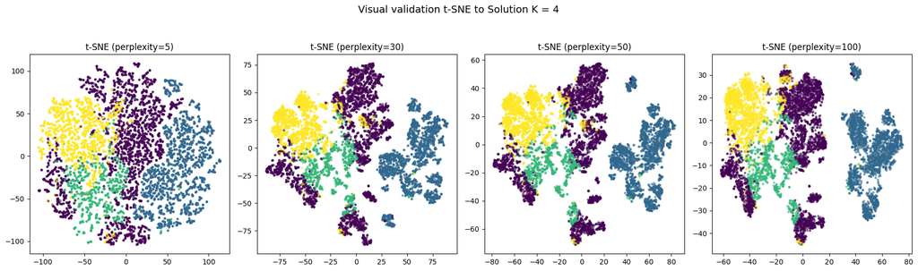

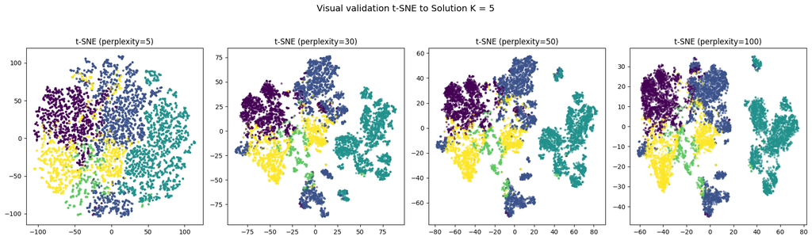

```python
# ---------------------------------------------------
# Validação t-SNE para k=4 e K5 já treinados
# ---------------------------------------------------

from sklearn.manifold import TSNE

# O t-SNE corre sobre os dados padronizados (X_scaled)
for k_test in [4, 5]:
    y_tsne = labels_kmeans[k_test]

    fig, axes = plt.subplots(1, 4, figsize=(18, 5))

    for ax, perp in zip(axes, [5, 30, 50, 100]):
        tsne = TSNE(n_components=2, perplexity=perp, random_state=42, init="pca")
        X_tsne = tsne.fit_transform(X_scaled) # Garante que usas a tua matriz X_scaled original

        sc = ax.scatter(
            X_tsne[:, 0], X_tsne[:, 1],
            c=y_tsne, cmap="viridis", s=6, alpha=0.5
        )
        ax.set_title(f"t-SNE (perplexity={perp})")

    plt.suptitle(f"Visual validation t-SNE to Solution K = {k_test}", fontsize=14, y=1.05)
    plt.tight_layout()
    fig.savefig(
        FIG_DIR / f"tSNE_perplexity_to_k4_k5_solutions_{k_test}.png",
        dpi=300,
        bbox_inches="tight"
    )
    plt.show()
```

## 4.6 DBSCAN

```
Seleção dos parâmetros
Treino do modelo
Resultados

Parâmetros:
    EPS
    MIN_SAMPLE (nº de vizinhos próximos)
```

### 4.6.1 Seleção dos parâmetros eps e min_samples

```python
from sklearn.cluster import DBSCAN
from sklearn.neighbors import NearestNeighbors

# Usar o NearestNeighbors

# escolha de eps por estimativa :: k-distance plot

# definir como min_sample =10  :: quais são os 10 postos mais próximos deste posto
neighbords = NearestNeighbors(n_neighbors=10)

# treina o modelo com a estrutura espacial dos dados
neighbords_fit = neighbords.fit(X_scaled)

# obter os X (10) vizinhos para cada um dos postos e as respetivas distâncias (usando os componentes PCA - mesmos usados no kmeans)
distances, indices = neighbords_fit.kneighbors(X_scaled)

distances = np.sort(distances[:, 9])
```

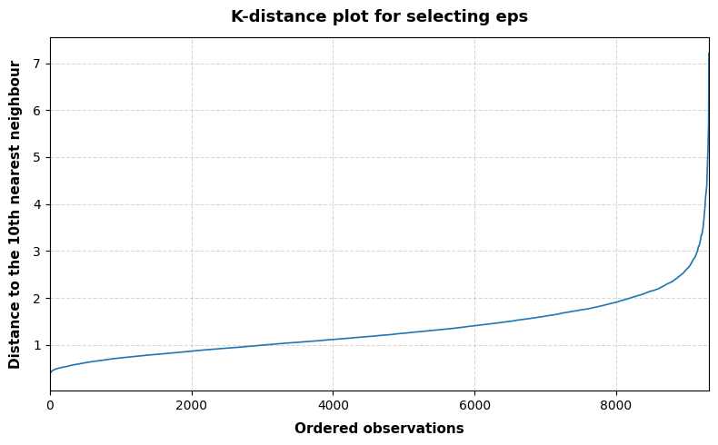

```python
# ---------------------------------------------------
# Plot k-distance
# ---------------------------------------------------
"""
    Para perceber qual o valor ideal para o eps
        - conforme o cotovelo do gráfico, o valor ideal deverá ser entre 1.8 e 2.2
"""
# Criar a figura
fig, ax = plt.subplots(figsize=(8, 5))

# Linha do gráfico
ax.plot(distances, color="#1f77b4", linewidth=1.2, label="10th-NN distance")

# Definir os rórutlos dos eixos
ax.set_xlabel("Ordered observations", fontsize=11, fontweight="bold", labelpad=8)
ax.set_ylabel(
    "Distance to the 10th nearest neighbour",
    fontsize=11,
    fontweight="bold",
    labelpad=8,
)
ax.set_title(
    "K-distance plot for selecting eps", fontsize=13, fontweight="bold", pad=12
)

# Criar a grelha de forma visualmente elegante
ax.grid(True, linestyle="--", alpha=0.3, color="gray", zorder=1)

# Remover os contornos superiores e direita
#ax.spines["top"].set_visible(False)
#ax.spines["right"].set_visible(False)

# Ajustar os limites do gráfico aos dados - evita espaços em branco se for o caso
ax.set_xlim(0, len(distances))

plt.tight_layout()

# Guardar a imagem em formato png
fig.savefig(
    FIG_DIR / f"dbscan_eps.png",
    dpi=300,
    bbox_inches="tight",
)

plt.show()
```

```python
# ----------------------------------------------------------------------------------------------------------------------------------------------
# este EPS=X,Y,Z para estimativa do valor de eps (identifcar outliers) --- usando o X_scaled (17 features originais)
# ----------------------------------------------------------------------------------------------------------------------------------------------

eps_candidates = [2.2, 2.4, 2.5, 2.8, 3.0] # StandardScaler # RobustScaler

min_samples = 10

dbscan_results = []
dbscan_labels = {}

for eps_test in eps_candidates:
    db = DBSCAN(eps=eps_test, min_samples=min_samples)
    labels_dbscan = db.fit_predict(X_scaled)

    # guardar as labels para usar nos outlieres abaixo
    dbscan_labels[eps_test] = labels_dbscan.copy()

    n_clusters = len(set(labels_dbscan)) - (1 if -1 in labels_dbscan else 0)
    n_noise = list(labels_dbscan).count(-1)

    dbscan_results.append({
        "EPS": eps_test,
        "n_clusters" : n_clusters,
        "n_noise" : n_noise,
        "pct_noise" : round(n_noise/len(labels_dbscan)*100, 1)
    })
    #print(pd.DataFrame(dbscan_results))
    dbscan_results_df = pd.DataFrame(dbscan_results)
    display(pd.DataFrame(dbscan_results))
```

|  | EPS | n_clusters | n_noise | pct_noise |
| --- | --- | --- | --- | --- |
| 0 | 2.2 | 6 | 284 | 3.1 |

|  | EPS | n_clusters | n_noise | pct_noise |
| --- | --- | --- | --- | --- |
| 0 | 2.2 | 6 | 284 | 3.1 |
| 1 | 2.4 | 3 | 190 | 2.0 |

|  | EPS | n_clusters | n_noise | pct_noise |
| --- | --- | --- | --- | --- |
| 0 | 2.2 | 6 | 284 | 3.1 |
| 1 | 2.4 | 3 | 190 | 2.0 |
| 2 | 2.5 | 3 | 161 | 1.7 |

|  | EPS | n_clusters | n_noise | pct_noise |
| --- | --- | --- | --- | --- |
| 0 | 2.2 | 6 | 284 | 3.1 |
| 1 | 2.4 | 3 | 190 | 2.0 |
| 2 | 2.5 | 3 | 161 | 1.7 |
| 3 | 2.8 | 3 | 84 | 0.9 |

|  | EPS | n_clusters | n_noise | pct_noise |
| --- | --- | --- | --- | --- |
| 0 | 2.2 | 6 | 284 | 3.1 |
| 1 | 2.4 | 3 | 190 | 2.0 |
| 2 | 2.5 | 3 | 161 | 1.7 |
| 3 | 2.8 | 3 | 84 | 0.9 |
| 4 | 3.0 | 2 | 64 | 0.7 |

```python
X_scaled.shape
```

```
(9309, 17)
```

### 4.6.4 HDBSCAN (Hierarchical DBSCAN)

```python
# ------------------------------------------------------------------------------------------------------
# HDBSCAN - com range e vários valores de min_cluster_size sobre as features originais
# ------------------------------------------------------------------------------------------------------

from sklearn.cluster import HDBSCAN

# variáveis - parametrizar :: algoritmo é por omissão auto, usa o kDTree
min_cluster_size = [15, 30, 50, 100, 150, 200, 400, 600]
min_samples = 10

hdbscan_results = []
hdbscan_labels = {}
hdbscan_probabilities = {}
hdbscan_models = {}

for m in min_cluster_size:
    print(f"\n--- A testar min_cluster_size = {m} ---")

    # instanciar o HDBSCAN
    hdbscan = HDBSCAN(
        min_cluster_size = m,
        min_samples = min_samples,
        metric = 'euclidean',
        copy = False
    )

    # treinar o modelo
    labels = hdbscan.fit_predict(X_scaled)

    # guarda as labels
    hdbscan_labels[m] = labels
    hdbscan_probabilities[m] = hdbscan.probabilities_.copy()

    n_clusters = len(set(labels)) - (1 if -1 in labels else 0)
    ruido = (labels == -1).sum()
    clusters = clusters = pd.Series(labels).value_counts().sort_index()

    hdbscan_results.append({
        "min_cluster_size": m,
        "ruido": ruido,
        "n_clusters": n_clusters,
        "probabilidade_media": hdbscan.probabilities_.mean(),
        "probabilidade_mediana": np.median(hdbscan.probabilities_)
    })

    # avaliar os resultados
    print(f"Nº de clusters encontrados: {n_clusters}")
    print(f"Qtd de pontos considerados ruído (-1): {ruido}")

    # ver a distribuição dos pontos por cluster
    print(f"Distribuição por cluster:")
    print(pd.Series(labels).value_counts().sort_index())

hdbscan_results_df = pd.DataFrame(hdbscan_results)
display(hdbscan_results_df)


# para usar as labels e as variáveis do hdbscan:
#labels = hdbscan_labels[100]
#display(pd.Series(labels).value_counts().sort_index())
```

```
--- A testar min_cluster_size = 15 ---
Nº de clusters encontrados: 11
Qtd de pontos considerados ruído (-1): 2599
Distribuição por cluster:
-1     2599
 0       25
 1       54
 2      155
 3     2180
 4       39
 5       26
 6     1822
 7      112
 8     2090
 9      176
 10      31
Name: count, dtype: int64

--- A testar min_cluster_size = 30 ---
Nº de clusters encontrados: 5
Qtd de pontos considerados ruído (-1): 832
Distribuição por cluster:
-1     832
 0      54
 1    6049
 2     155
 3    2180
 4      39
Name: count, dtype: int64

--- A testar min_cluster_size = 50 ---
Nº de clusters encontrados: 4
Qtd de pontos considerados ruído (-1): 650
Distribuição por cluster:
-1     650
 0      54
 1    2401
 2    6049
 3     155
Name: count, dtype: int64
```

[output cut: 35 more lines]

```
Distribuição por cluster:
-1    2338
 0    2401
 1    2748
 2    1822
Name: count, dtype: int64

--- A testar min_cluster_size = 600 ---
Nº de clusters encontrados: 2
Qtd de pontos considerados ruído (-1): 676
Distribuição por cluster:
-1     676
 0    6232
 1    2401
Name: count, dtype: int64
```

|  | min_cluster_size | ruido | n_clusters | probabilidade_media | probabilidade_mediana |
| --- | --- | --- | --- | --- | --- |
| 0 | 15 | 2599 | 11 | 0.658132 | 0.865783 |
| 1 | 30 | 832 | 5 | 0.863550 | 1.000000 |
| 2 | 50 | 650 | 4 | 0.873985 | 1.000000 |
| 3 | 100 | 704 | 3 | 0.869190 | 1.000000 |
| 4 | 150 | 2520 | 5 | 0.613823 | 0.750660 |
| 5 | 200 | 676 | 2 | 0.867293 | 1.000000 |
| 6 | 400 | 2338 | 3 | 0.568764 | 0.685351 |
| 7 | 600 | 676 | 2 | 0.842426 | 1.000000 |

```python
df_final = df_features.copy()
```

## 4.6.5 Labels clusters

Criação de variáveis para simplificar o uso e a chamada aos modelos já treinados durante o processo de seleção do valor de K final para o K-Means.

```python
cluster_labels = {
    "kmeans": labels_kmeans,
    "dbscan": dbscan_labels,
    "hdbscan": hdbscan_labels
}

"""
# para usar as labels e as variáveis do hdbscan:
labels = hdbscan_labels[100]
display(pd.Series(labels).value_counts().sort_index())

"""
```

```
'\n# para usar as labels e as variáveis do hdbscan:\nlabels = hdbscan_labels[100]\ndisplay(pd.Series(labels).value_counts().sort_index())\n\n'
```

```python
#  --- k-MEANS ---
df_final["cluster_kmeans_k4"] = cluster_labels["kmeans"][4]
df_final["cluster_kmeans_k5"] = cluster_labels["kmeans"][5]

# --- HDBSCAN ---
df_final["cluster_hdbscan_v1"] = cluster_labels["hdbscan"][30]
df_final["cluster_hdbscan_v2"] = cluster_labels["hdbscan"][50]


# --- Probailidades HDBSCAN ---
df_final["prob_hdbscan_m30"] = hdbscan_probabilities[30]
df_final["prob_hdbscan_m50"] = hdbscan_probabilities[50]
```

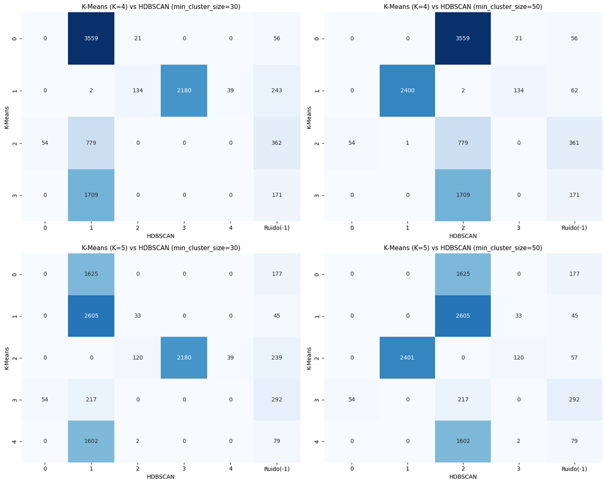

```python
# -----------------------------------------------------------------------------------------------------
# --- Comparação usando heatmaps para os Ks (4 e 5) e os cluster_min_size = 30 e 50
# -----------------------------------------------------------------------------------------------------
import matplotlib.pyplot as plt
import seaborn as sns
import pandas as pd

comparisons = [
    (4, 30),
    (4, 50),
    (5, 30),
    (5, 50)
]

# Construir primeiro todas as tabelas
tables = {}
vmax = 0

for k, m in comparisons:
    table = pd.crosstab(
        cluster_labels["kmeans"][k],
        cluster_labels["hdbscan"][m]
    )

    # Reordenar as colunas: spara que a coluna de ruído (-1) fique no fim
    cols = list(table.columns)
    if -1 in cols:
        cols.remove(-1)
        cols = cols + [-1]
        table = table[cols]

    # Renomear a coluna -1 para "Ruido(-1)"
    table = table.rename(columns={-1: "Ruido(-1)"})

    tables[(k, m)] = table
    vmax = max(vmax, table.to_numpy().max())

# Figura 2x2
fig, axes = plt.subplots(2, 2, figsize=(15, 12))

for ax, (k, m) in zip(axes.flat, comparisons):

    sns.heatmap(
        tables[(k, m)],
        annot=True,
        fmt="d",
        cmap="Blues",
        vmin=0,
        vmax=vmax,
        cbar=False,
        ax=ax
    )

    ax.set_title(
        f"K-Means (K={k}) vs HDBSCAN (min_cluster_size={m})",
        fontsize=11
    )
    ax.set_xlabel("HDBSCAN")
    ax.set_ylabel("K-Means")

#plt.suptitle(
#    "Comparison between K-Means and HDBSCAN cluster assignments",
#    fontsize=14,
#    fontweight="bold"
#)

plt.tight_layout()

# Guardar a imagem em formato png
fig.savefig(
    FIG_DIR / f"hdbscan_k4_k5_perplexity30_50.png",
    dpi=300,
    bbox_inches="tight",
)
plt.show()
```

```python
# ----------------------------------------------------------
# Parâmetros selecionados
# K selecionado=4 :: EPS=2.5 :: MIN_CLUSTER_SIZE_FINAL=50
# ----------------------------------------------------------

K_FINAL = 4
EPS_FINAL = 2.5
MIN_CLUSTER_SIZE_FINAL = 50

# Criar/renovar o dataframe consolidado
df_final = df_features.copy()

df_final["cluster_kmeans"] = (
    cluster_labels["kmeans"][K_FINAL]
)

df_final["cluster_dbscan"] = (
    cluster_labels["dbscan"][EPS_FINAL]
)

df_final["cluster_hdbscan"] = (
    cluster_labels["hdbscan"][MIN_CLUSTER_SIZE_FINAL]
)

# Componentes PCA, se forem necessárias posteriormente
for i in range(X_pca.shape[1]):
    df_final[f"PC{i+1}"] = X_pca[:, i]

#print(df_final.columns)
display(
    df_final[
        ["cluster_kmeans", "cluster_dbscan", "cluster_hdbscan"]
    ].head()
)
```

|  | cluster_kmeans | cluster_dbscan | cluster_hdbscan |
| --- | --- | --- | --- |
| 0 | 0 | 0 | 2 |
| 1 | 0 | 0 | 2 |
| 2 | 3 | 0 | 2 |
| 3 | 3 | 0 | 2 |
| 4 | 0 | 0 | 2 |

```python
# ------------------------------------------------------------------------------------------------------
# Comparar e apresentar num quadro os resultados sobre o modelo já treinado com k=4, com os algoritmos:
#       -- k-Means
#       -- BISECTING K-MEANS
#       -- GAUSSIAN MIXTURE MODEL
#       -- AGGLOMERATIVE CLUSTERING
# ------------------------------------------------------------------------------------------------------
import pandas as pd

from sklearn.cluster import BisectingKMeans
from sklearn.mixture import GaussianMixture
from sklearn.cluster import AgglomerativeClustering
from sklearn.metrics import (
    silhouette_score,
    davies_bouldin_score,
    calinski_harabasz_score
)

# K selecionado
k_ideal = 4
print(f"--- A treinar modelos alternativos com K={k_ideal} sobre o espaço PCA ---")

# --------------------------------------------------
# 1. K-MEANS ORIGINAL
# Reutilizar o modelo e as labels já calculados
# --------------------------------------------------

kmeans_model = models_kmeans[k_ideal]
kmeans_labels = labels_kmeans[k_ideal]


# --------------------------------------------------
# 2. BISECTING K-MEANS
# --------------------------------------------------

bkm = BisectingKMeans(
    n_clusters=k_ideal,
    random_state=42
)

bkm_labels = bkm.fit_predict(X_pca)


# --------------------------------------------------
# 3. GAUSSIAN MIXTURE MODEL
# --------------------------------------------------

gmm = GaussianMixture(
    n_components=k_ideal,
    covariance_type="full",
    random_state=42,
    n_init=10
)

gmm_labels = gmm.fit_predict(X_pca)

# --------------------------------------------------
# 4. AGGLOMERATIVE CLUSTERING
# --------------------------------------------------

agmc = AgglomerativeClustering(
    n_clusters=k_ideal,
    linkage="ward"          # ‘ward’ minimizes the variance of the clusters being merged
)

agmc_labels = agmc.fit_predict(X_pca)

# --------------------------------------------------
# 4. Função auxiliar para calcular métricas
# --------------------------------------------------

def calcular_metricas(nome_algoritmo, labels):
    return {
        "Algoritmo": nome_algoritmo,
        "Silhouette": silhouette_score(
            X_pca,
            labels
        ),
        "Davies-Bouldin": davies_bouldin_score(
            X_pca,
            labels
        ),
        "Calinski-Harabasz": calinski_harabasz_score(
            X_pca,
            labels
        ),
        "n_clusters": len(set(labels)),
        "Distribuição dos postos": dict(
            pd.Series(labels)
            .value_counts()
            .sort_index()
        )
    }

# --------------------------------------------------
# 5. Quadro comparativo
# --------------------------------------------------

resultados_algoritmos = [
    calcular_metricas(
        "K-Means",
        kmeans_labels
    ),
    calcular_metricas(
        "Bisecting K-Means",
        bkm_labels
    ),
    calcular_metricas(
        "Gaussian Mixture Model",
        gmm_labels
    ),
    calcular_metricas(
        "Agglomerative Clustering Model",
        agmc_labels
    )
]

df_comparativo = pd.DataFrame(resultados_algoritmos)

display(
    df_comparativo.style.format({
        "Silhouette": "{:.3f}",
        "Davies-Bouldin": "{:.3f}",
        "Calinski-Harabasz": "{:.2f}"
    })
)
```

```
--- A treinar modelos alternativos com K=4 sobre o espaço PCA ---
```

|  | Algoritmo | Silhouette | Davies-Bouldin | Calinski-Harabasz | n_clusters | Distribuição dos postos |
| --- | --- | --- | --- | --- | --- | --- |
| 0 | K-Means | 0.291 | 1.353 | 3475.52 | 4 | {0: np.int64(3636), 1: np.int64(2598), 2: np.int64(1195), 3: np.int64(1880)} |
| 1 | Bisecting K-Means | 0.268 | 1.413 | 3316.46 | 4 | {0: np.int64(1691), 1: np.int64(1700), 2: np.int64(3184), 3: np.int64(2734)} |
| 2 | Gaussian Mixture Model | 0.246 | 1.699 | 2684.11 | 4 | {0: np.int64(3321), 1: np.int64(2387), 2: np.int64(2610), 3: np.int64(991)} |
| 3 | Agglomerative Clustering Model | 0.196 | 1.563 | 2690.46 | 4 | {0: np.int64(3685), 1: np.int64(2623), 2: np.int64(1978), 3: np.int64(1023)} |

### 4.6.5 Análise dos outliers

```python
df_final["cluster_kmeans"] = (
    cluster_labels["kmeans"][K_FINAL]
)

df_final["cluster_dbscan"] = (
    cluster_labels["dbscan"][EPS_FINAL]
)

df_final["cluster_hdbscan"] = (
    cluster_labels["hdbscan"][MIN_CLUSTER_SIZE_FINAL]
)

# Componentes PCA, se forem necessárias posteriormente
for i in range(X_pca.shape[1]):
    df_final[f"PC{i+1}"] = X_pca[:, i]

display(
    df_final[
        ["cluster_kmeans", "cluster_dbscan", "cluster_hdbscan"]
    ].head()
)
```

|  | cluster_kmeans | cluster_dbscan | cluster_hdbscan |
| --- | --- | --- | --- |
| 0 | 0 | 0 | 2 |
| 1 | 0 | 0 | 2 |
| 2 | 3 | 0 | 2 |
| 3 | 3 | 0 | 2 |
| 4 | 0 | 0 | 2 |

```python
print(cluster_labels["dbscan"].keys())
print(cluster_labels["hdbscan"].keys())
```

```
dict_keys([2.2, 2.4, 2.5, 2.8, 3.0])
dict_keys([15, 30, 50, 100, 150, 200, 400, 600])
```

```python
# ---------------------------------------------------
# Identificar outliers
# ---------------------------------------------------

# = -1 identificados como não pertencendo a nenhum grupo
outliers = df_final.loc[df_final["cluster_dbscan"].eq(-1)].copy()

# conta o número de linhas existentes no dataframe
n_total = len(df_final)
n_outliers = len(outliers)

# calcular a percentagem de outliers com base no total existente no original
pct_outliers = n_outliers / n_total * 100

print(f"N.º total de postos: {n_total}")
print(f"N.º de outliers DBSCAN: {n_outliers}")
print(f"Percentagem de outliers: {pct_outliers:.2f}%")
```

```
N.º total de postos: 9309
N.º de outliers DBSCAN: 161
Percentagem de outliers: 1.73%
```

```python
# Identificar outliers
outliers.head()
```

|  | id_charging_station | distrito | municipio | dtmn | nuts_3 | nuts_2 | nuts_1 | geom | sessoes_mes_ativo | kwh_mes_ativo | ... | cluster_kmeans | cluster_dbscan | cluster_hdbscan | PC1 | PC2 | PC3 | PC4 | PC5 | PC6 | PC7 |
| --- | --- | --- | --- | --- | --- | --- | --- | --- | --- | --- | --- | --- | --- | --- | --- | --- | --- | --- | --- | --- | --- |
| 64 | ABF-00093 | Faro | Albufeira | 0801 | Algarve | Algarve | Continente | 0101000020B30E0000239AE711181BC2C0FF295F34E439... | 4.0 | 91.0000 | ... | 2 | -1 | -1 | -1.410297 | -3.602612 | 2.980339 | -1.197414 | 2.478096 | 2.173621 | -1.032673 |
| 117 | ACB-00025 | Leiria | Alcobaça | 1001 | Oeste | Oeste e Vale do Tejo | Continente | 0101000020B30E0000CFE4AD88906FF1C0AFA77D85752C... | 1.5 | 8.4075 | ... | 2 | -1 | -1 | -0.988715 | -2.737098 | 3.640963 | 3.944422 | 3.014017 | -2.975280 | 2.409371 |
| 218 | AJT-00013 | Beja | Aljustrel | 0201 | Baixo Alentejo | Alentejo | Continente | 0101000020B30E000055EB8EAC24B6C2C0128A457211A4... | 273.5 | 7808.1300 | ... | 1 | -1 | -1 | 4.875011 | 0.185634 | 0.091356 | 3.473581 | -3.135743 | -0.398045 | 1.657011 |
| 259 | ALD-00009 | Guarda | Almeida | 0902 | Beiras e Serra da Estrela | Centro | Continente | 0101000020B30E000002BBC2C0F266F840FAE785506A8F... | 2.0 | 75.3400 | ... | 2 | -1 | -1 | 1.603087 | -4.983000 | 4.827558 | -0.737007 | 0.296397 | 0.544442 | 2.193788 |
| 260 | ALD-00011 | Guarda | Almeida | 0902 | Beiras e Serra da Estrela | Centro | Continente | 0101000020B30E000009297883B667F8402877C7FE528F... | 3.0 | 68.0600 | ... | 1 | -1 | -1 | 2.103076 | -3.633831 | 6.697216 | 0.665173 | 1.310333 | -2.432127 | 3.404600 |

5 rows × 36 columns

```python
outliers[features].median()
```

```
sessoes_mes_ativo                  2.000000
kwh_mes_ativo                     17.576667
energia_media_kwh                 10.030000
duracao_media_min                 81.631561
pct_fim_semana                     0.000000
pct_periodo_descanso               0.125000
pct_horario_laboral                0.372943
pct_verao                          0.000000
pct_inverno                        0.000000
n_evse_instalados                  2.000000
n_conectores_instalados            2.000000
potencia_max_kw                   22.000000
potencia_total_kw                 44.000000
tem_dc                             0.000000
tem_rapido                         0.000000
sessoes_por_conector_instalado     2.000000
kwh_por_kw_instalado               0.650909
dtype: float64
```

# Estatísticas dos outliers

```python
cols_outliers = [
    "sessoes_mes_ativo",
    "kwh_mes_ativo",
    "energia_media_kwh",
    "duracao_media_min",
    "potencia_total_kw",
    "n_evse_instalados"
]
network_median = df_final[cols_outliers].median()
outlier_median = outliers[cols_outliers].median()

comparison_outliers = pd.DataFrame({
    "mediana_rede": network_median,
    "mediana_outliers": outlier_median
})
comparison_outliers["dif_relativa"] = (
    comparison_outliers["mediana_outliers"]
    / comparison_outliers["mediana_rede"]
)
display(comparison_outliers.round(2))
```

|  | mediana_rede | mediana_outliers | dif_relativa |
| --- | --- | --- | --- |
| sessoes_mes_ativo | 22.24 | 2.00 | 0.09 |
| kwh_mes_ativo | 413.61 | 17.58 | 0.04 |
| energia_media_kwh | 19.41 | 10.03 | 0.52 |
| duracao_media_min | 150.46 | 81.63 | 0.54 |
| potencia_total_kw | 44.00 | 44.00 | 1.00 |
| n_evse_instalados | 2.00 | 2.00 | 1.00 |

```python
# ---------------------------------------------------
# Distribuição territorial dos outliers
# ---------------------------------------------------
district_outlier_summary = (
    df_final
    .assign(is_outlier=df_final["cluster_dbscan"].eq(-1))
    .groupby("distrito")
    .agg(
        n_postos=("is_outlier", "size"),
        n_outliers=("is_outlier", "sum")
    )
)
district_outlier_summary["pct_outliers"] = (
    district_outlier_summary["n_outliers"]
    / district_outlier_summary["n_postos"]
    * 100
)
district_outlier_summary = (
    district_outlier_summary
    .sort_values("pct_outliers", ascending=False)
    .round(2)
)

display(district_outlier_summary.head(10))
```

| distrito | n_postos | n_outliers | pct_outliers |
| --- | --- | --- | --- |
| Guarda | 97 | 4 | 4.12 |
| Vila Real | 111 | 4 | 3.60 |
| Castelo Branco | 133 | 4 | 3.01 |
| Aveiro | 437 | 13 | 2.97 |
| Beja | 138 | 4 | 2.90 |
| Viana do Castelo | 154 | 4 | 2.60 |
| Santarém | 317 | 8 | 2.52 |
| Évora | 142 | 3 | 2.11 |
| Braga | 536 | 11 | 2.05 |
| Porto | 1383 | 25 | 1.81 |

```python
outliers_distrito = (
    outliers["distrito"]
    .value_counts()
    .rename_axis("distrito")
    .reset_index(name="n_outliers")
)

display(outliers_distrito.head(20))
```

|  | distrito | n_outliers |
| --- | --- | --- |
| 0 | Lisboa | 52 |
| 1 | Porto | 25 |
| 2 | Aveiro | 13 |
| 3 | Braga | 11 |
| 4 | Faro | 8 |
| 5 | Santarém | 8 |
| 6 | Setúbal | 7 |
| 7 | Leiria | 5 |
| 8 | Beja | 4 |
| 9 | Guarda | 4 |
| 10 | Coimbra | 4 |
| 11 | Vila Real | 4 |
| 12 | Viana do Castelo | 4 |
| 13 | Castelo Branco | 4 |
| 14 | Évora | 3 |
| 15 | Viseu | 3 |
| 16 | Bragança | 1 |
| 17 | Portalegre | 1 |

```python
# Estatística dos outliers
outlier_stats = outliers[
    [
        "sessoes_mes_ativo",
        "kwh_mes_ativo",
        "energia_media_kwh",
        "duracao_media_min",
        "potencia_total_kw",
        "n_evse_instalados"
    ]
].describe().round(2)

outlier_stats
```

|  | sessoes_mes_ativo | kwh_mes_ativo | energia_media_kwh | duracao_media_min | potencia_total_kw | n_evse_instalados |
| --- | --- | --- | --- | --- | --- | --- |
| count | 161.00 | 161.00 | 161.00 | 161.00 | 161.00 | 161.00 |
| mean | 9.93 | 191.33 | 13.49 | 180.67 | 135.73 | 2.14 |
| std | 44.72 | 978.28 | 12.86 | 247.77 | 396.32 | 1.77 |
| min | 1.00 | 0.10 | 0.10 | 2.28 | 3.70 | 1.00 |
| 25% | 1.00 | 5.20 | 3.12 | 19.22 | 14.80 | 1.00 |
| 50% | 2.00 | 17.58 | 10.03 | 81.63 | 44.00 | 2.00 |
| 75% | 3.00 | 46.72 | 21.25 | 228.06 | 120.00 | 2.00 |
| max | 327.87 | 7808.13 | 56.50 | 1679.85 | 4400.00 | 12.00 |

```python
# ---------------------------------------------------
# Top 20 outliers
# ---------------------------------------------------
outliers = anonymise_station_labels(outliers)

top20_outliers_sessoes = outliers[
    [
        "station_label",
        "distrito",
        "municipio",
        "sessoes_mes_ativo",
        "kwh_mes_ativo",
        "energia_media_kwh",
        "potencia_total_kw"
    ]
].sort_values(
    "sessoes_mes_ativo",
    ascending=False
).head(20)

top20_outliers_sessoes
```

|  | station_label | distrito | municipio | sessoes_mes_ativo | kwh_mes_ativo | energia_media_kwh | potencia_total_kw |
| --- | --- | --- | --- | --- | --- | --- | --- |
| 2876 | CS039 | Lisboa | Lisboa | 327.869565 | 4474.242522 | 13.646410 | 396.0 |
| 2875 | CS038 | Lisboa | Lisboa | 325.095238 | 4804.933238 | 14.780079 | 396.0 |
| 218 | CS003 | Beja | Aljustrel | 273.500000 | 7808.130000 | 28.548921 | 1800.0 |
| 2094 | CS027 | Guarda | Guarda | 210.000000 | 7341.396333 | 34.959030 | 4400.0 |
| 7758 | CS145 | Faro | Portimão | 33.000000 | 363.750000 | 11.022727 | 29.6 |
| 1694 | CS021 | Évora | Évora | 23.000000 | 74.940000 | 3.258261 | 11.0 |
| 353 | CS007 | Santarém | Almeirim | 17.000000 | 410.800000 | 24.164706 | 176.0 |
| 7719 | CS144 | Faro | Portimão | 15.000000 | 465.960000 | 31.064000 | 22.0 |
| 2345 | CS032 | Faro | Loulé | 13.166667 | 313.350000 | 23.798734 | 264.0 |
| 3232 | CS048 | Lisboa | Lisboa | 12.000000 | 194.995000 | 16.249583 | 614.4 |
| 3220 | CS046 | Lisboa | Lisboa | 11.000000 | 243.634000 | 22.148545 | 144.0 |
| 6606 | CS126 | Setúbal | Montijo | 10.000000 | 192.050000 | 19.205000 | 100.0 |
| 7185 | CS134 | Santarém | Ourém | 8.000000 | 114.330000 | 14.291250 | 22.0 |
| 7948 | CS150 | Setúbal | Santiago do Cacém | 8.000000 | 170.950000 | 21.368750 | 710.0 |
| 6884 | CS131 | Beja | Odemira | 8.000000 | 66.990000 | 8.373750 | 7.4 |
| 4036 | CS057 | Leiria | Caldas da Rainha | 8.000000 | 164.520000 | 20.565000 | 120.0 |
| 6243 | CS118 | Porto | Santo Tirso | 7.000000 | 23.490000 | 3.355714 | 14.8 |
| 1849 | CS023 | Castelo Branco | Fundão | 7.000000 | 99.320000 | 14.188571 | 143.0 |
| 2489 | CS035 | Leiria | Leiria | 6.666667 | 184.150000 | 27.622500 | 48.0 |
| 5453 | CS087 | Vila Real | Murça | 6.533333 | 2.014400 | 0.308327 | 3.7 |

```python
# ---------------------------------------------------
# Botton 20
# ---------------------------------------------------
bottom20_outliers_sessoes = outliers[
    [
        "station_label",
        "distrito",
        "municipio",
        "sessoes_mes_ativo",
        "kwh_mes_ativo",
        "energia_media_kwh",
        "potencia_total_kw"
    ]
].sort_values(
    "sessoes_mes_ativo",
    ascending=True
).head(20)

bottom20_outliers_sessoes
```

|  | station_label | distrito | municipio | sessoes_mes_ativo | kwh_mes_ativo | energia_media_kwh | potencia_total_kw |
| --- | --- | --- | --- | --- | --- | --- | --- |
| 9226 | CS161 | Vila Real | Vila Pouca de Aguiar | 1.0 | 1.500 | 1.500 | 59.2 |
| 5900 | CS104 | Porto | Penafiel | 1.0 | 50.100 | 50.100 | 200.0 |
| 4131 | CS062 | Lisboa | Cascais | 1.0 | 56.100 | 56.100 | 7.4 |
| 4075 | CS061 | Lisboa | Cascais | 1.0 | 2.000 | 2.000 | 22.0 |
| 4070 | CS059 | Lisboa | Cascais | 1.0 | 5.550 | 5.550 | 22.0 |
| 4049 | CS058 | Lisboa | Cascais | 1.0 | 12.655 | 12.655 | 14.8 |
| 5990 | CS106 | Porto | Porto | 1.0 | 2.700 | 2.700 | 22.0 |
| 3949 | CS055 | Braga | Braga | 1.0 | 10.235 | 10.235 | 14.8 |
| 3939 | CS053 | Braga | Braga | 1.0 | 1.270 | 1.270 | 7.4 |
| 3733 | CS051 | Santarém | Almeirim | 1.0 | 0.525 | 0.525 | 22.0 |
| 6038 | CS109 | Braga | Barcelos | 1.0 | 2.200 | 2.200 | 22.0 |
| 3230 | CS047 | Lisboa | Lisboa | 1.0 | 33.460 | 33.460 | 29.6 |
| 6120 | CS113 | Lisboa | Sintra | 1.0 | 0.750 | 0.750 | 7.4 |
| 6141 | CS114 | Lisboa | Sintra | 1.0 | 31.270 | 31.270 | 22.2 |
| 5467 | CS090 | Aveiro | Oliveira do Bairro | 1.0 | 13.000 | 13.000 | 7.4 |
| 6163 | CS115 | Coimbra | Soure | 1.0 | 18.270 | 18.270 | 22.0 |
| 5899 | CS103 | Porto | Penafiel | 1.0 | 14.100 | 14.100 | 200.0 |
| 5669 | CS098 | Lisboa | Oeiras | 1.0 | 0.700 | 0.700 | 44.0 |
| 4369 | CS069 | Lisboa | Loures | 1.0 | 41.400 | 41.400 | 22.0 |
| 4376 | CS070 | Lisboa | Loures | 1.0 | 28.900 | 28.900 | 7.4 |

```python
outliers.groupby("distrito").agg({
    "sessoes_mes_ativo": "median",
    "kwh_mes_ativo": "median",
    "potencia_total_kw": "median"
}).sort_values(
    "sessoes_mes_ativo",
    ascending=False
)
```

| distrito | sessoes_mes_ativo | kwh_mes_ativo | potencia_total_kw |
| --- | --- | --- | --- |
| Leiria | 5.000000 | 8.407500 | 120.0 |
| Beja | 5.000000 | 37.340000 | 11.1 |
| Évora | 3.000000 | 66.320000 | 22.0 |
| Santarém | 3.000000 | 46.163333 | 22.0 |
| Faro | 3.000000 | 65.645000 | 55.0 |
| Guarda | 2.500000 | 71.700000 | 380.0 |
| Viana do Castelo | 2.000000 | 15.430000 | 47.8 |
| Setúbal | 2.000000 | 37.580000 | 120.0 |
| Aveiro | 2.000000 | 13.000000 | 44.0 |
| Castelo Branco | 2.000000 | 40.055000 | 121.5 |
| Braga | 2.000000 | 7.823000 | 14.8 |
| Vila Real | 1.600000 | 9.922700 | 80.6 |
| Porto | 1.500000 | 11.290000 | 44.0 |
| Viseu | 1.500000 | 15.080000 | 44.0 |
| Lisboa | 1.416667 | 18.769750 | 22.0 |
| Coimbra | 1.214286 | 9.868333 | 55.0 |
| Portalegre | 1.000000 | 25.300000 | 120.0 |
| Bragança | 1.000000 | 6.350000 | 22.0 |

```python
# ---------------------------------------------------
# Distribuição por nutsIII
# ---------------------------------------------------
(
    pd.crosstab(
        df_final["nuts_3"],
        df_final["cluster_kmeans"],
        normalize="index"
    ) * 100
).round(1)
```

| cluster_kmeans nuts_3 | 0 | 1 | 2 | 3 |
| --- | --- | --- | --- | --- |
| Alentejo Central | 36.6 | 38.7 | 7.0 | 17.6 |
| Alentejo Litoral | 38.2 | 37.4 | 7.6 | 16.8 |
| Algarve | 49.5 | 30.0 | 7.3 | 13.1 |
| Alto Alentejo | 52.2 | 27.5 | 7.2 | 13.0 |
| Alto Minho | 36.4 | 37.0 | 11.7 | 14.9 |
| Alto Tâmega e Barroso | 54.5 | 18.2 | 11.4 | 15.9 |
| Ave | 38.8 | 35.4 | 7.6 | 18.1 |
| Baixo Alentejo | 33.9 | 46.0 | 12.1 | 8.1 |
| Beira Baixa | 38.4 | 38.4 | 9.6 | 13.7 |
| Beiras e Serra da Estrela | 33.3 | 45.3 | 10.0 | 11.3 |
| Cávado | 26.5 | 27.9 | 17.0 | 28.6 |
| Douro | 45.1 | 31.0 | 9.7 | 14.2 |
| Grande Lisboa | 45.4 | 16.7 | 17.0 | 20.8 |
| Lezíria do Tejo | 23.5 | 34.2 | 14.8 | 27.6 |
| Médio Tejo | 39.4 | 43.7 | 5.6 | 11.3 |
| Oeste | 37.1 | 34.9 | 7.0 | 21.0 |
| Península de Setúbal | 37.7 | 27.7 | 8.1 | 26.4 |
| Região de Aveiro | 26.6 | 40.7 | 13.7 | 19.1 |
| Região de Coimbra | 34.9 | 32.4 | 18.1 | 14.6 |
| Região de Leiria | 35.2 | 41.1 | 11.0 | 12.7 |
| Terras de Trás-os-Montes | 36.4 | 50.9 | 7.3 | 5.5 |
| Tâmega e Sousa | 28.3 | 41.1 | 13.9 | 16.7 |
| Viseu Dão Lafões | 36.2 | 31.9 | 16.5 | 15.4 |
| Área Metropolitana do Porto | 31.6 | 32.2 | 10.4 | 25.8 |

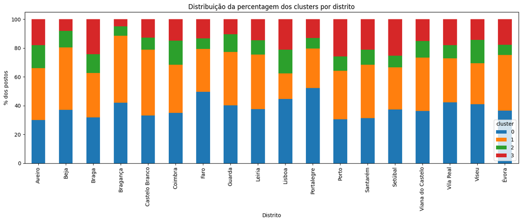

```python
# -----------------------------------------------------------------------------------------------------
# Plot da distribuição com a percentagem de clusters por distrito
# -----------------------------------------------------------------------------------------------------
cluster_distrito_pct = (
    pd.crosstab(
        df_final["distrito"],
        df_final["cluster_kmeans"],
        normalize="index"
    ) * 100
)

cluster_distrito_pct.plot(
    kind="bar",
    stacked=True,
    figsize=(14, 6)
)

plt.ylabel("% dos postos")
plt.xlabel("Distrito")
plt.title("Distribuição da percentagem dos clusters por distrito")
plt.legend(title="cluster")
plt.tight_layout()
plt.show()
```

### 4.6.5 Distribuição espaciacial dos clusters e outliers

```python
import geopandas as gpd
import pandas as pd

from shapely import wkb, wkt
from shapely.geometry.base import BaseGeometry


def parse_geometry(value):
    """Converter geometria Shapely, WKB ou WKT para objeto geométrico."""
    if value is None:
        return None

    if isinstance(value, BaseGeometry):
        return value

    if isinstance(value, bytes):
        return wkb.loads(value)

    if isinstance(value, str):
        try:
            return wkt.loads(value)
        except Exception:
            try:
                return wkb.loads(bytes.fromhex(value))
            except Exception:
                return None

    return None


# Cópia do dataframe consolidado
df_spatial = df_final.copy()

# Se df_final não tiver geom, recuperá-la do dataframe original
if "geom" not in df_spatial.columns:
    df_spatial = df_spatial.merge(
        df[["id_charging_station", "geom"]],
        on="id_charging_station",
        how="left",
        validate="one_to_one"
    )

# Converter a geometria
df_spatial["geometry"] = df_spatial["geom"].apply(parse_geometry)

# Criar GeoDataFrame
gdf_final = gpd.GeoDataFrame(
    df_spatial,
    geometry="geometry",
    crs="EPSG:3763"
)

print(f"N.º de postos: {len(gdf_final):,}")
print(f"Geometrias nulas: {gdf_final.geometry.isna().sum()}")
print(gdf_final.crs)
```

```
N.º de postos: 9,309
Geometrias nulas: 0
EPSG:3763
```

```python
query_caop = """
    SELECT
        distrito,
        municipio,
        geom
    FROM v00_caop_municipios
    WHERE nuts_1 = 'Continente';
"""

gdf_municipios = gpd.read_postgis(
    query_caop,
    con=engine,
    geom_col="geom"
).to_crs(epsg=3763)

gdf_distritos = (
    gdf_municipios
    .dissolve(by="distrito")
)
```

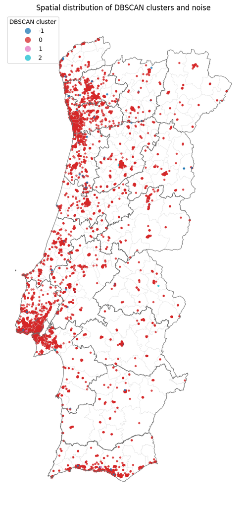

```python
fig, ax = plt.subplots(figsize=(9, 12))

gdf_municipios.boundary.plot(
    ax=ax,
    linewidth=0.25,
    color="lightgray",
    alpha=0.7
)

gdf_distritos.boundary.plot(
    ax=ax,
    linewidth=0.8,
    color="dimgray",
    alpha=0.9
)

gdf_final.plot(
    column="cluster_dbscan",
    categorical=True,
    legend=True,
    markersize=7,
    alpha=0.75,
    ax=ax,
    cmap="tab10",
    legend_kwds={
        "title": "DBSCAN cluster",
        "loc": "upper left"
    }
)

ax.set_title("Spatial distribution of DBSCAN clusters and noise")
ax.set_axis_off()

plt.tight_layout()

fig.savefig(
    FIG_DIR / "dbscan_spatial_distribution_NB04.png",
    dpi=300,
    bbox_inches="tight"
)

plt.show()
```

[output not shown]

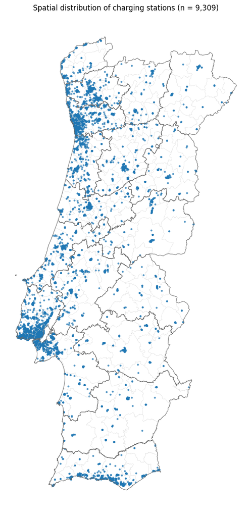

```python
fig, ax = plt.subplots(figsize=(9, 12))

gdf_municipios.boundary.plot(
    ax=ax,
    linewidth=0.25,
    color="lightgray",
    alpha=0.7
)

gdf_distritos.boundary.plot(
    ax=ax,
    linewidth=0.8,
    color="dimgray",
    alpha=0.9
)

gdf_final.plot(
    ax=ax,
    markersize=5,
    alpha=0.65
)

ax.set_title(
    f"Spatial distribution of charging stations "
    f"(n = {len(gdf_final):,})"
)
ax.set_axis_off()

plt.tight_layout()
"""
fig.savefig(
    FIG_DIR / "charging_stations_spatial_distribution_NB04.png",
    dpi=300,
    bbox_inches="tight"
)"""

#plt.show()
```

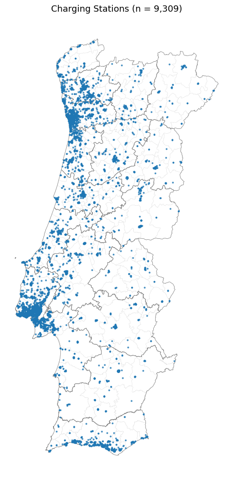

```python
munic.plot_categories_with_boundaries(
    gdf_points=gdf_final,
    column="id_charging_station",
    title=f"Charging Stations (n = {len(gdf_final):,})",
    outfile="charging_stations_spatial_distribution_NB04.png",
    gdf_mun=gdf_municipios
)
```

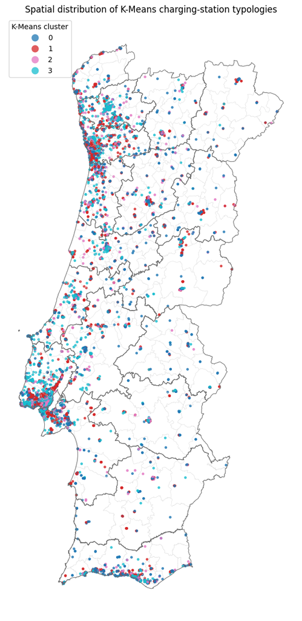

```python
fig, ax = plt.subplots(figsize=(9, 12))

gdf_municipios.boundary.plot(
    ax=ax,
    linewidth=0.25,
    color="lightgray",
    alpha=0.7
)

gdf_distritos.boundary.plot(
    ax=ax,
    linewidth=0.8,
    color="dimgray",
    alpha=0.9
)

gdf_final.plot(
    column="cluster_kmeans",
    categorical=True,
    legend=True,
    markersize=7,
    alpha=0.75,
    ax=ax,
    cmap="tab10",
    legend_kwds={
        "title": "K-Means cluster",
        "loc": "upper left"
    }
)

ax.set_title(
    "Spatial distribution of K-Means charging-station typologies"
)
ax.set_axis_off()

plt.tight_layout()

fig.savefig(
    FIG_DIR / "kmeans_k4_spatial_distribution_NB04.png",
    dpi=300,
    bbox_inches="tight"
)

plt.show()
```

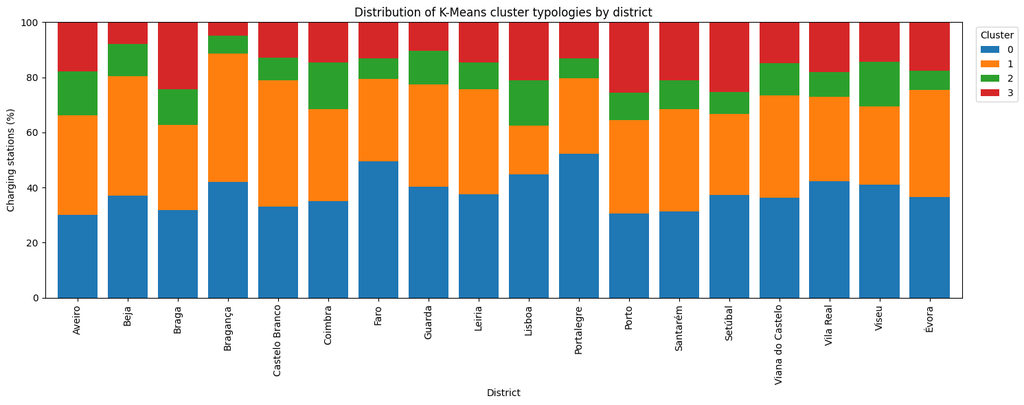

```python
cluster_distrito_pct = (
    pd.crosstab(
        gdf_final["distrito"],
        gdf_final["cluster_kmeans"],
        normalize="index"
    )
    .mul(100)
)

cluster_distrito_pct = cluster_distrito_pct.sort_index()

ax = cluster_distrito_pct.plot(
    kind="bar",
    stacked=True,
    figsize=(15, 6),
    width=0.8
)

ax.set_title(
    "Distribution of K-Means cluster typologies by district"
)
ax.set_xlabel("District")
ax.set_ylabel("Charging stations (%)")
ax.legend(
    title="Cluster",
    bbox_to_anchor=(1.01, 1),
    loc="upper left"
)
ax.set_ylim(0, 100)

plt.xticks(rotation=90)
plt.tight_layout()

fig = ax.get_figure()

fig.savefig(
    FIG_DIR / "kmeans_cluster_distribution_by_district_NB04.png",
    dpi=300,
    bbox_inches="tight"
)

plt.show()
```

```python
DISTRITO = "Coimbra"

gdf_coimbra = gdf_final[
    gdf_final["distrito"]
    .str.upper()
    .eq(DISTRITO.upper())
].copy()

print(f"Postos no distrito de Coimbra: {len(gdf_coimbra):,}")
print(
    gdf_coimbra["cluster_kmeans"]
    .value_counts()
    .sort_index()
)
```

```
Postos no distrito de Coimbra: 285
cluster_kmeans
0    100
1     95
2     48
3     42
Name: count, dtype: int64
```

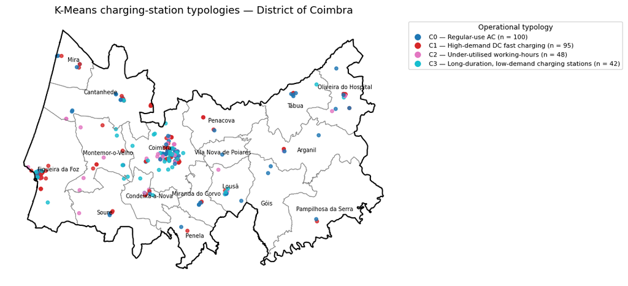

```python
from matplotlib.lines import Line2D

# Preparar dataframe para a função de representação
gdf_coimbra_plot = gdf_coimbra.rename(
    columns={"cluster_kmeans": "cluster"}
).copy()

# Limites municipais do Distrito de Coimbra
mun_coimbra = munic.get_limites_distrito(
    DISTRITO,
    engine
)

# Criar mapa
fig, ax = munic.plot_clusters_distrito(
    gdf_coimbra_plot,
    mun_coimbra,
    DISTRITO
)

# Mesmas cores utilizadas no mapa
CLUSTER_COLORS = {
    0: "#1f77b4",
    1: "#d62728",
    2: "#e377c2",
    3: "#17becf"
}

CLUSTER_LABELS = {
    0: "C0 — Regular-use AC",
    1: "C1 — High-demand DC fast charging",
    2: "C2 — Under-utilised working-hours",
    3: "C3 — Long-duration, low-demand charging stations"
}

# Contagem final por cluster
cluster_counts = (
    gdf_coimbra_plot["cluster"]
    .value_counts()
    .sort_index()
)

# Criar manualmente os elementos da legenda
legend_handles = [
    Line2D(
        [0],
        [0],
        marker="o",
        linestyle="",
        markerfacecolor=CLUSTER_COLORS[c],
        markeredgecolor=CLUSTER_COLORS[c],
        markersize=7,
        label=(
            f"{CLUSTER_LABELS[c]} "
            f"(n = {cluster_counts.get(c, 0):,})"
        )
    )
    for c in sorted(CLUSTER_LABELS)
]

# Substituir a legenda numérica por uma legenda interpretável
ax.legend(
    handles=legend_handles,
    title="Operational typology",
    loc="upper left",
    bbox_to_anchor=(1.01, 1.0),
    fontsize=8,
    title_fontsize=9,
    frameon=True
)

# Título mais coerente com a tese
ax.set_title(
    "K-Means charging-station typologies — District of Coimbra",
    fontsize=13
)

fig.savefig(
    FIG_DIR / f"cluster_kmeans_{DISTRITO.lower()}_NB04.png",
    dpi=300,
    bbox_inches="tight",
    pad_inches=0.15
)

plt.show()
```

```python
display(
    gdf_coimbra_plot["cluster"]
    .value_counts()
    .sort_index()
)
```

```
cluster
0    100
1     95
2     48
3     42
Name: count, dtype: int64
```

```python
print("Original:")
print(gdf_coimbra[["cluster_kmeans"]].head(20))

print("\nAfter rename:")
print(gdf_coimbra_plot[["cluster"]].head(20))
```

```
Original:
      cluster_kmeans
204                1
205                2
206                1
207                0
208                0
1018               1
1019               1
1020               0
1021               0
1022               0
1023               0
1024               1
1025               1
```

[output cut: 30 more lines]

```python
print("Cluster distribution — Coimbra:")
print(
    gdf_coimbra_plot["cluster"]
    .value_counts()
    .sort_index()
)
```

```
Cluster distribution — Coimbra:
cluster
0    100
1     95
2     48
3     42
Name: count, dtype: int64
```

## 4.9 Export clusters

```python
cols_export = [
    "id_charging_station",
    "distrito",
    "municipio",
    "dtmn",
    "cluster_kmeans",
    "cluster_dbscan",
    "cluster_hdbscan"
]

clusters_export = (
    gdf_final[cols_export]
    .copy()
)

clusters_export.to_csv(
    "../outputs/clusters_nacional_NB04.csv",
    index=False
)

print(
    f"Exportados {len(clusters_export):,} postos para "
    "../outputs/clusters_nacional_NB04.csv"
)
```

```
Exportados 9,309 postos para ../outputs/clusters_nacional_NB04.csv
```

```python
clusters_kmeans = df_final[
    [
        "id_charging_station",
        "cluster_kmeans"
    ]
].copy()

clusters_kmeans = clusters_kmeans.rename(columns={"cluster_kmeans": "cluster"} )

clusters_kmeans.to_csv("../outputs/clusters_kmeans_k4_final.csv", index=False)
```